# Applied machine learning - tidymodels

Regression Demo: Predicting concrete strength

Dr. Joseph P. Yurko

Fall 2021 Semester

## Overview

Let’s get some practice going through a complete data analysis project from start to finish. We will explore, visualize, clean, and train models for a regression application. Specifically, we will predictive the compressive strength of concrete using a widely available and popular data set. This report demonstrates preparing data for predictive models, and considers various kinds of *preprocessing* steps that we should consider. Linear methods and advanced non-linear methods are used, many of which you will learn more about later in the course.

We will work with the `tidymodels` library in this report. `tidymodels` is a suite of packages that provide modeling *workflows* following the `tidyverse` philosophy and mindset. Numerous packages will be used within this report, most but not all are installed with `tidymodels`. The code chunk below loads in `tidymodels` and so brings in a suite of packages that will we will work with. Additional packages will be loaded later in the report.

```r
library(tidymodels)
tidymodels_prefer()
```

If you would like additional practice, [Ch. 15 in the tidy modeling with R book](https://www.tmwr.org/workflow-sets.html) demonstrates modeling with `tidymodels` with the same example data set. The book focuses on several advanced `tidymodels` functions which streamline organizing, training, and tuning multiple models. This report focuses on individual models and then combines the results for model comparison and selection at the end.

## Data

```r
data("concrete", package = "modeldata")

concrete %>% glimpse()
```

```
## Rows: 1,030
## Columns: 9
## $ cement               <dbl> 540.0, 540.0, 332.5, 332.5, 198.6, 266.0, 380.0, ~
## $ blast_furnace_slag   <dbl> 0.0, 0.0, 142.5, 142.5, 132.4, 114.0, 95.0, 95.0,~
## $ fly_ash              <dbl> 0, 0, 0, 0, 0, 0, 0, 0, 0, 0, 0, 0, 0, 0, 0, 0, 0~
## $ water                <dbl> 162, 162, 228, 228, 192, 228, 228, 228, 228, 228,~
## $ superplasticizer     <dbl> 2.5, 2.5, 0.0, 0.0, 0.0, 0.0, 0.0, 0.0, 0.0, 0.0,~
## $ coarse_aggregate     <dbl> 1040.0, 1055.0, 932.0, 932.0, 978.4, 932.0, 932.0~
## $ fine_aggregate       <dbl> 676.0, 676.0, 594.0, 594.0, 825.5, 670.0, 594.0, ~
## $ age                  <int> 28, 28, 270, 365, 360, 90, 365, 28, 28, 28, 90, 2~
## $ compressive_strength <dbl> 79.99, 61.89, 40.27, 41.05, 44.30, 47.03, 43.70, ~
```

### Data preparation

The glimpse above reveals that all variables in `concrete` are numeric. Thus, we do not have any categorical or discrete variables in this application. We can use the `summary()` function to print out useful summary statistics associated with each variable in the data set.

```r
concrete %>% summary()
```

```
##      cement      blast_furnace_slag    fly_ash           water
##  Min.   :102.0   Min.   :  0.0      Min.   :  0.00   Min.   :121.8
##  1st Qu.:192.4   1st Qu.:  0.0      1st Qu.:  0.00   1st Qu.:164.9
##  Median :272.9   Median : 22.0      Median :  0.00   Median :185.0
##  Mean   :281.2   Mean   : 73.9      Mean   : 54.19   Mean   :181.6
##  3rd Qu.:350.0   3rd Qu.:142.9      3rd Qu.:118.30   3rd Qu.:192.0
##  Max.   :540.0   Max.   :359.4      Max.   :200.10   Max.   :247.0
##  superplasticizer coarse_aggregate fine_aggregate       age
##  Min.   : 0.000   Min.   : 801.0   Min.   :594.0   Min.   :  1.00
##  1st Qu.: 0.000   1st Qu.: 932.0   1st Qu.:731.0   1st Qu.:  7.00
##  Median : 6.400   Median : 968.0   Median :779.5   Median : 28.00
##  Mean   : 6.205   Mean   : 972.9   Mean   :773.6   Mean   : 45.66
##  3rd Qu.:10.200   3rd Qu.:1029.4   3rd Qu.:824.0   3rd Qu.: 56.00
##  Max.   :32.200   Max.   :1145.0   Max.   :992.6   Max.   :365.00
##  compressive_strength
##  Min.   : 2.33
##  1st Qu.:23.71
##  Median :34.45
##  Mean   :35.82
##  3rd Qu.:46.13
##  Max.   :82.60
```

Let’s next check for the number of unique values and confirm the number of missings. Even though we printed the summary stats above, let’s include the min, median, and max values again for reference.

```r
tibble::tibble(
  variable = names(concrete),
  num_missing = map_dbl(concrete, ~sum(is.na(.))),
  num_unique = map_dbl(concrete, n_distinct),
  min_value = map_dbl(concrete, min),
  median_value = map_dbl(concrete, median),
  max_value = map_dbl(concrete, max)
) %>%
  knitr::kable(caption = "concrete variables overview")
```

concrete variables overview

| variable | num_missing | num_unique | min_value | median_value | max_value |
| --- | --- | --- | --- | --- | --- |
| cement | 0 | 278 | 102.00 | 272.900 | 540.0 |
| blast_furnace_slag | 0 | 185 | 0.00 | 22.000 | 359.4 |
| fly_ash | 0 | 156 | 0.00 | 0.000 | 200.1 |
| water | 0 | 195 | 121.80 | 185.000 | 247.0 |
| superplasticizer | 0 | 111 | 0.00 | 6.400 | 32.2 |
| coarse_aggregate | 0 | 284 | 801.00 | 968.000 | 1145.0 |
| fine_aggregate | 0 | 302 | 594.00 | 779.500 | 992.6 |
| age | 0 | 14 | 1.00 | 28.000 | 365.0 |
| compressive_strength | 0 | 845 | 2.33 | 34.445 | 82.6 |

As shown above, the `age` variable has just 14 unique values, while all other variables have at least one hundred values or more. We might be tempted to view the `age` variable has categorical because there are relatively few unique values. However, it is also important to know and understand the context of a data set and the application we are working on. The `age` variable is fundamentally numeric, providing the time (referred to as the “age”) of a concrete specimen when it is tested. The fact that there are just 14 values for `age` represents the common times used in the industry that produces concrete.

This is a *supervised learning* or *predictive modeling* application. Thus, some variables are **inputs**, while another variable is an **output**, **response**, or **outcome** of interest. In this specific application, we want to *predict* or *model* the `compressive_strength` as a function of the other variables in the data set.

The previous table showed the number of unique values for each variable. Let’s now consider the number of unique *combinations* of all inputs. As shown below, there are 992 unique combinations of the 8 inputs. The `concrete` data has 1030 rows, thus some combinations are **replicated** multiple times.

```r
concrete %>%
  select(-compressive_strength) %>%
  distinct() %>%
  dim()
```

```
## [1] 992   8
```

From a statistical point of view, replication is a *good thing*. Replication allows us to consider the repeability (or lack there of) of an experiment, configuration, design, or process. The code chunk below identifies the unique input *configurations*, and displays to the screen the number of configurations that have been replicated more than once.

```r
concrete_configs <- concrete %>%
  select(-compressive_strength) %>%
  group_by(across()) %>%
  summarise(num_rows = n(), .groups = 'drop') %>%
  tibble::rowid_to_column("set_id")

concrete_configs %>%
  filter(num_rows > 1) %>%
  nrow()
```

```
## [1] 19
```

As confirmation, the code chunk below displays one of the unique input configurations to the screen. Notice that `rowid` is changing across the rows, while `set_id` is constant. Each row is a separate row in the `concrete` tibble, but the 8 inputs have the exact same values.

```r
input_names <- concrete %>% select(-compressive_strength) %>% names()

concrete %>%
  tibble::rowid_to_column() %>%
  left_join(concrete_configs,
            by = input_names) %>%
  filter(num_rows > 1) %>%
  arrange(desc(num_rows)) %>%
  slice(1:4) %>%
  select(rowid, set_id, num_rows, all_of(names(concrete))) %>%
  knitr::kable()
```

| rowid | set_id | num_rows | cement | blast_furnace_slag | fly_ash | water | superplasticizer | coarse_aggregate | fine_aggregate | age | compressive_strength |
| --- | --- | --- | --- | --- | --- | --- | --- | --- | --- | --- | --- |
| 84 | 783 | 4 | 362.6 | 189 | 0 | 164.9 | 11.6 | 944.7 | 755.8 | 3 | 35.3 |
| 87 | 783 | 4 | 362.6 | 189 | 0 | 164.9 | 11.6 | 944.7 | 755.8 | 3 | 35.3 |
| 89 | 783 | 4 | 362.6 | 189 | 0 | 164.9 | 11.6 | 944.7 | 755.8 | 3 | 35.3 |
| 92 | 783 | 4 | 362.6 | 189 | 0 | 164.9 | 11.6 | 944.7 | 755.8 | 3 | 35.3 |

It is important to note that the 4 rows shown above are **not** duplicates. They are **replications**. Although the response, `compressive_strength` is also constant for the specific input configuration, we must also check the response behavior of the other 18 replicated configurations. The code chunk below visualizes the `compressive_strength` as a strip plot for the 19 replicated input configurations. As reference, the count (number of observations) is represented by the marker size. The minimum and maximum response values per configuration are connected by a vertical grey line to better visualize the range. The minimum and maximum values associated with `compressive_strength` are displayed by horizontal grey lines to give further context about the magnitude of the variation. As shown below, there are multiple configurations with identical values for the response, and thus no variation across the replications. However, there are also configurations with different response values even though the input configurations are the same! Several configurations appear to have small variation (about 5 units or less), while others have moderate variation (about 10 units). One configuration, `set_id = 784`, has a range (difference between max and min) of more than 20 units! If we were working with this dataset at a company or in a research project, we would want to learn more about the data collection and entry process to make sure an error did not occur when the low value with `set_id = 784` was recorded.

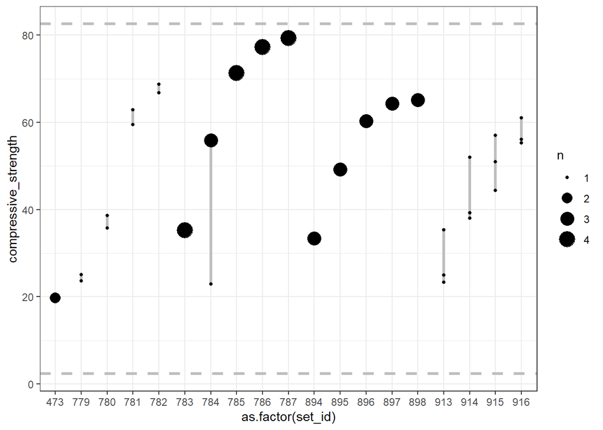

```r
concrete %>%
  left_join(concrete_configs,
            by = input_names) %>%
  filter(num_rows > 1) %>%
  ggplot(mapping = aes(x = as.factor(set_id), y = compressive_strength)) +
  stat_summary(geom = 'linerange',
               fun.min = min, fun.max = max,
               mapping = aes(group = set_id),
               color = 'grey', size = 1.1) +
  geom_count() +
  geom_hline(yintercept = range(concrete$compressive_strength),
             color = 'grey', linetype = 'dashed', size = 1.2) +
  theme_bw()
```

The above figure reveals a grouping of the replication variability: no variation, small, moderate, and the extreme variation. It would be interesting to check if such grouping structure was associated with an interval of one of the inputs or combination of a few inputs. However, we will not go examine such behavior in this report.

We must decide how we will handle the replicate variations in our data set. The correct approach would be to include the replication variability as an unknown parameter, separate from the residual error of the model. We would therefore handle the hierarchical structure of the data: variation due to changing the inputs, and the natural process variation which is natural in all manufacturing processes (if you are interested the field of statistical quality or process control is focused on monitoring and understand drivers of variability). However, appropriately capturing the two sources of error is outside the scope of this example. Instead, we will follow the same simplification used in [Ch. 15 in the tidy modeling with R book](https://www.tmwr.org/workflow-sets.html), namely we will average the response of the replicate configurations. The tidy modeling with R book (tmwr) describes averaging the response so that the cross-validation strategy will not yield overconfident performance metrics due to configurations with no variability having the same response value. This is a valid concern, but if we approapriately handled the hierarchical nature of the data, the cross-validation would be applied to unique configurations, not necessarily individual measurements. Again, we will not go into such an approach here, and so we will simply average the response as done in tmwr.

Before averaging, let’s visualize the average response and the confidence interval on the average for the replicate configurations. This will help us understand the consequence of our choice, relative to the original *raw* measurements. The average and confidence interval are dispalyed by the red marker and error bars in the graph below. As we can see, the mean is a good proxy for the configurations with small response variability. However, the moderate variability configurations show the mean may not be representative of any of the measurements. This is especially true for `set_id = 784` where the mean is obviously different from the extreme lower measurement value.

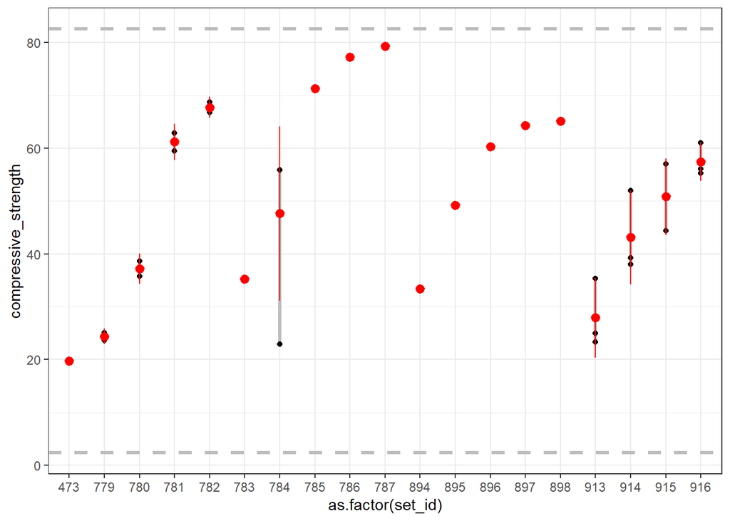

```r
concrete %>%
  left_join(concrete_configs,
            by = input_names) %>%
  filter(num_rows > 1) %>%
  ggplot(mapping = aes(x = as.factor(set_id), y = compressive_strength)) +
  stat_summary(geom = 'linerange',
               fun.min = min, fun.max = max,
               mapping = aes(group = set_id),
               color = 'grey', size = 1.1) +
  geom_point() +
  stat_summary(fun.data = 'mean_se',
               color = 'red',
               mapping = aes(group = set_id),
               fun.args = list(mult = 2)) +
  geom_hline(yintercept = range(concrete$compressive_strength),
             color = 'grey', linetype = 'dashed', size = 1.2) +
  theme_bw()
```

We are “splitting the difference” between measurements by “replacing” the raw measurements with the grouped average response per input configuration. Having to make such choices are common in data analysis applications. By using the average and ignoring the replication variability we will be under representing the uncertainty in the response. This is acceptable for now because we are primarily demonstrating the approach. A complete analysis would require that we also consider the hierarchical nature of the data.

The code chunk below performs the averaging and assigns the result to the `my_concrete` object.

```r
my_concrete <- concrete %>%
  group_by(across(cement:age)) %>%
  summarise(compressive_strength = mean(compressive_strength),
            .groups = 'drop')
```

Let’s confirm the number of rows in the prepared data set is less than what we had originally.

```r
my_concrete %>% dim()
```

```
## [1] 992   9
```

```r
nrow(my_concrete) < nrow(concrete)
```

```
## [1] TRUE
```

### Visual exploration

Even though we have prepared the data in the format that we will use for modeling, we are not ready to start modeling. We must first visualize the data! Histograms for all inputs and the response are shown in the graphic below.

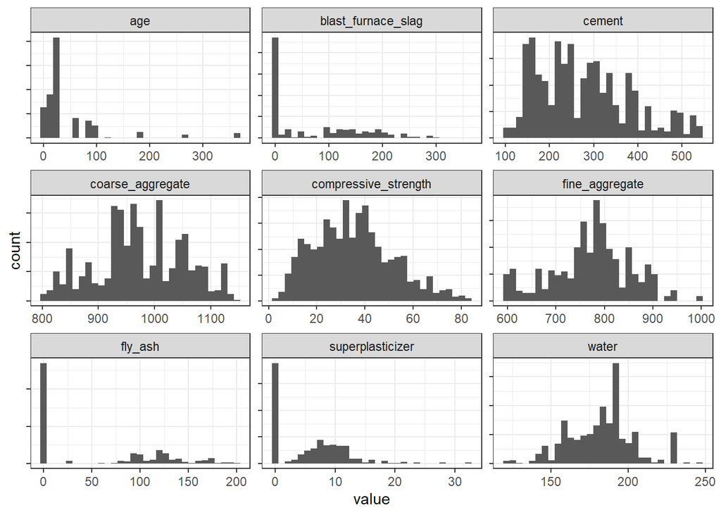

```r
my_concrete %>%
  tibble::rowid_to_column() %>%
  pivot_longer(!c("rowid")) %>%
  ggplot(mapping = aes(x = value)) +
  geom_histogram(bins = 31) +
  facet_wrap(~name, scales = "free") +
  theme_bw() +
  theme(axis.text.y = element_blank())
```

The above figure reveals several important aspects of the variables. We already knew `age` has just 14 unique values. The observations are concentrated at lower aging times, resulting in a highly right skewed distribution. Let’s focus on `age` treating it as a discrete variable just so we can get a better view of the *proportion* associated with each unique value. The bar graph below shows the proportion of observations for each unique value. The bar graph below reveals that over 40% of the observations have `age = 28`. Please note that `age` is not categorical for reasons described earlier. It is presented that way just so we can focus on the specific values present in the data set.

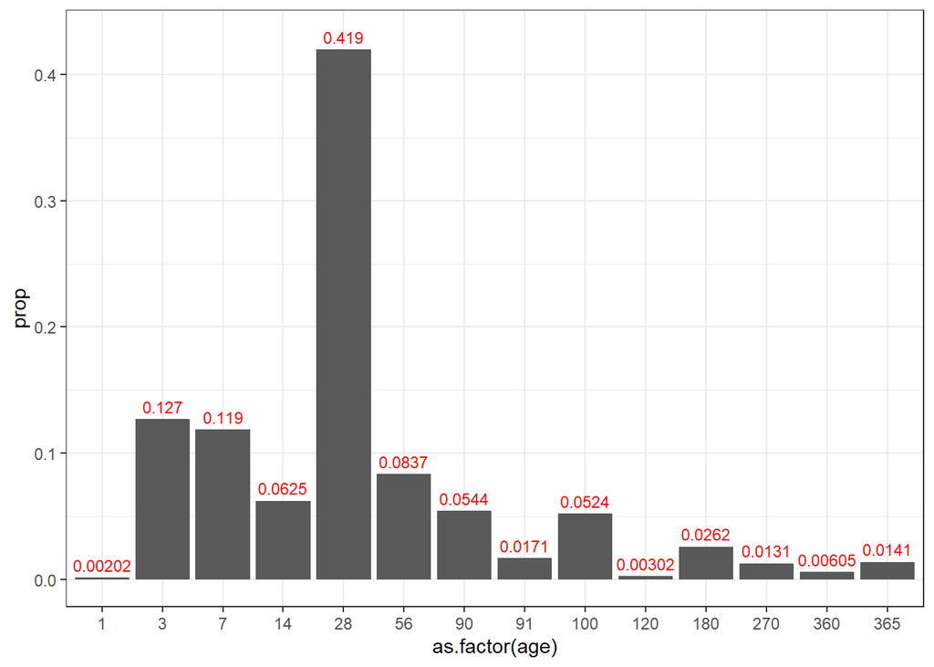

```r
my_concrete %>%
  ggplot(mapping = aes(x = as.factor(age))) +
  geom_bar(mapping = aes(y = stat(prop),
                         group = 1)) +
  geom_text(stat = 'count',
            mapping = aes(y = after_stat( count / sum(count) ),
                          label = after_stat( signif(count / sum(count), 3) )),
            color = 'red', nudge_y = 0.01, size = 3) +
  theme_bw()
```

The other major finding from the facetted (subplots) histograms was that three variables had “spikes” close to zero. The histograms for those three variables are presented again below.

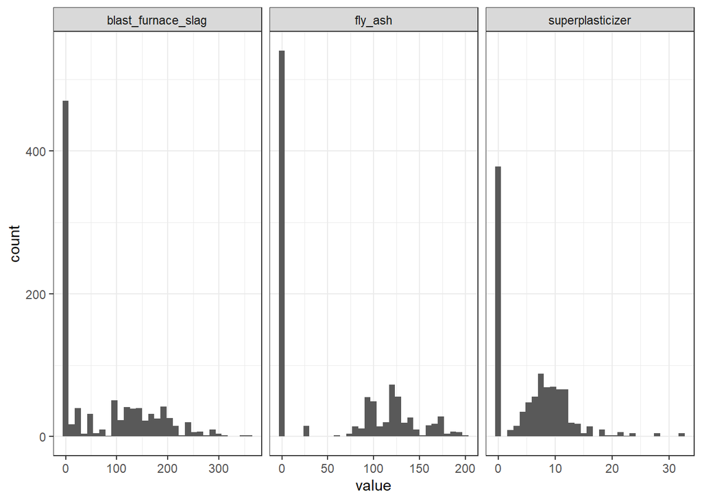

```r
my_concrete %>%
  select(blast_furnace_slag, fly_ash, superplasticizer) %>%
  tibble::rowid_to_column() %>%
  pivot_longer(!c("rowid")) %>%
  ggplot(mapping = aes(x = value)) +
  geom_histogram(bins = 31) +
  facet_wrap(~name, scales = "free_x") +
  theme_bw()
```

It seems that the three variables have at least 300 observations with values very close to zero. The code chunk below checks if those values are truly identically zero, or just the result of the histogram binning. As the tibble print out shows, `fly_ash` has about 54% of the observations identically equal to zero. `superplasticizer` has about 38% of the observations identically zero, and `blast_furnace_slag` has about 47% of the observations identically equal to zero.

```r
my_concrete %>%
  select(blast_furnace_slag, fly_ash, superplasticizer) %>%
  tibble::rowid_to_column() %>%
  pivot_longer(!c("rowid")) %>%
  group_by(name) %>%
  summarise(num_rows = n(),
            num_equal_zero = sum(value == 0),
            frac_equal_zero = mean(value == 0),
            .groups = "drop")
```

```
## # A tibble: 3 x 4
##   name               num_rows num_equal_zero frac_equal_zero
##   <chr>                 <int>          <int>           <dbl>
## 1 blast_furnace_slag      992            470           0.474
## 2 fly_ash                 992            540           0.544
## 3 superplasticizer        992            378           0.381
```

These three variables have complicated distributions. They are *mixtures*. First there’s a categorical representation, “does the value equal zero?”. If the value is greater than zero, the three have continuous distributions. Working with such mixture type inputs can be challenging.

The number of identically zero observations presented above do not consider combinations of the variables. We focused on each variable separately. Let’s now consider if the three variables frequently equal zero at the same time. The graphic below visualizes the counts of equal to zero or not equal to zero with a bar chart. The counts associated with `blast_furnace_slag` are represented by the facets. The graphic below reveals that `superplasticizer` rarely equals zero when `fly_ash` does not equal zero, regardless of the value of `blast_furnace_slag`. This suggests there is a relationship for how the *binarized* version of the variables are structured.

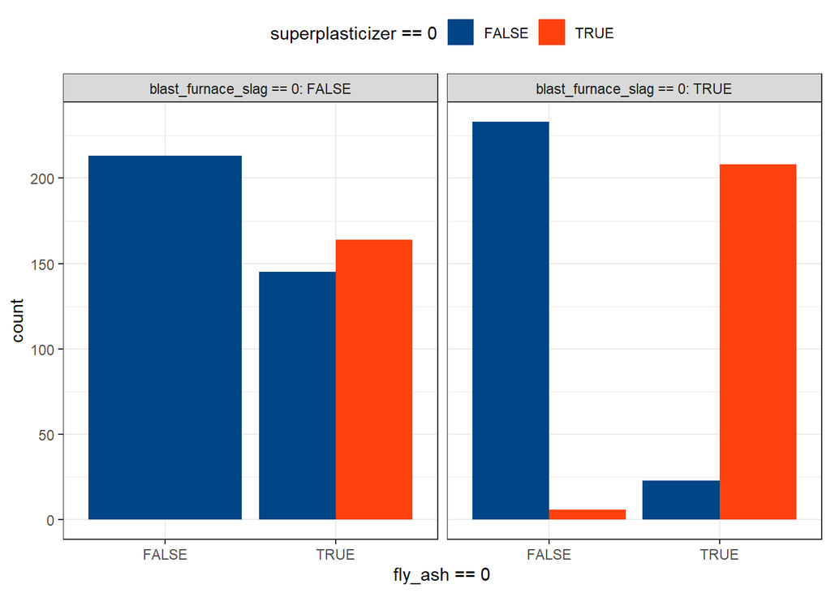

```r
my_concrete %>%
  ggplot(mapping = aes(x = fly_ash == 0)) +
  geom_bar(mapping = aes(fill = superplasticizer == 0),
           position = 'dodge') +
  facet_wrap( ~ blast_furnace_slag == 0, labeller = "label_both") +
  ggthemes::scale_fill_calc() +
  theme_bw() +
  theme(legend.position = "top")
```

Alternatively, we can visualize the combinations as a heat map. The information visualized below is the same as what was visualized in the above bar graph. Consider which graphic type is easier for you to interpret.

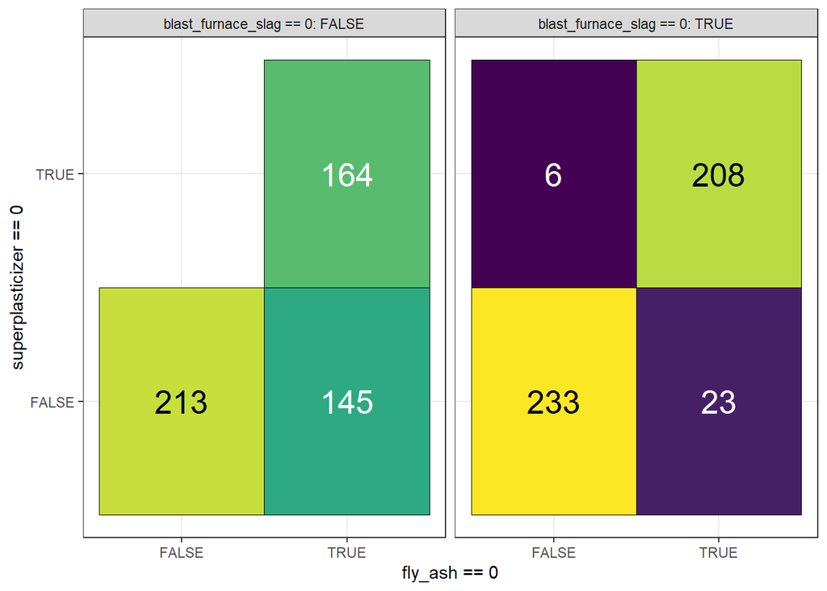

```r
my_concrete %>%
  count(fly_ash == 0, superplasticizer == 0, blast_furnace_slag == 0) %>%
  ggplot(mapping = aes(x = `fly_ash == 0`, y = `superplasticizer == 0`)) +
  geom_tile(mapping = aes(fill = n),
            color = 'black') +
  geom_text(mapping = aes(label = n,
                          color = n > median(n)),
            size = 7) +
  facet_wrap( ~ `blast_furnace_slag == 0`, labeller = "label_both") +
  scale_fill_viridis_c(guide = 'none') +
  scale_color_manual(guide = 'none',
                     values = c("TRUE" = 'black',
                                "FALSE" = 'white')) +
  theme_bw()
```

Since we previously identified about 40% of the observations of `age` correspond to a single value, let’s also check the counts when `age == 28`.

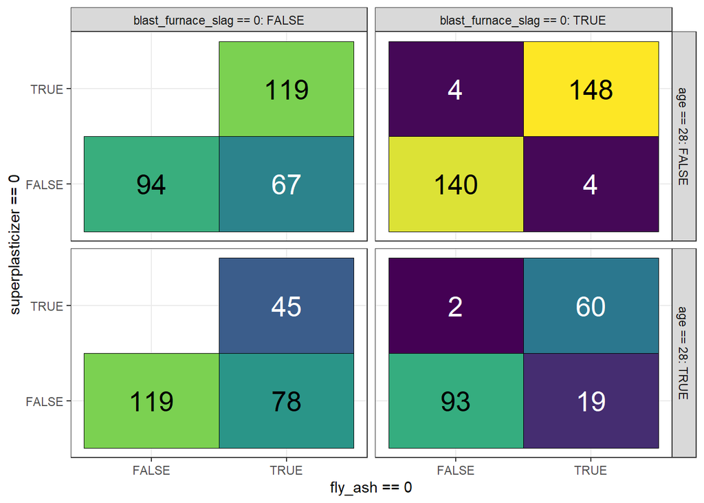

```r
my_concrete %>%
  count(fly_ash == 0, superplasticizer == 0,
        blast_furnace_slag == 0,
        age == 28) %>%
  ggplot(mapping = aes(x = `fly_ash == 0`, y = `superplasticizer == 0`)) +
  geom_tile(mapping = aes(fill = n),
            color = 'black') +
  geom_text(mapping = aes(label = n,
                          color = n > median(n)),
            size = 7) +
  facet_grid( `age == 28` ~ `blast_furnace_slag == 0`, labeller = "label_both") +
  scale_fill_viridis_c(guide = 'none') +
  scale_color_manual(guide = 'none',
                     values = c("TRUE" = 'black',
                                "FALSE" = 'white')) +
  theme_bw()
```

Let’s next look at the relationship between the continuous values of the three *mixture* type variables. A scatter plot between `superplasticizer` and `fly_ash` is shown below. The facet separates the data based on if `blast_furnace_slag` is equal to zero or not. The marker color represents the `blast_furnace_slag` value. All markers in the `blast_furnace_slag == 0` facet have the same color because `blast_furnace_slag` is constant in that group.

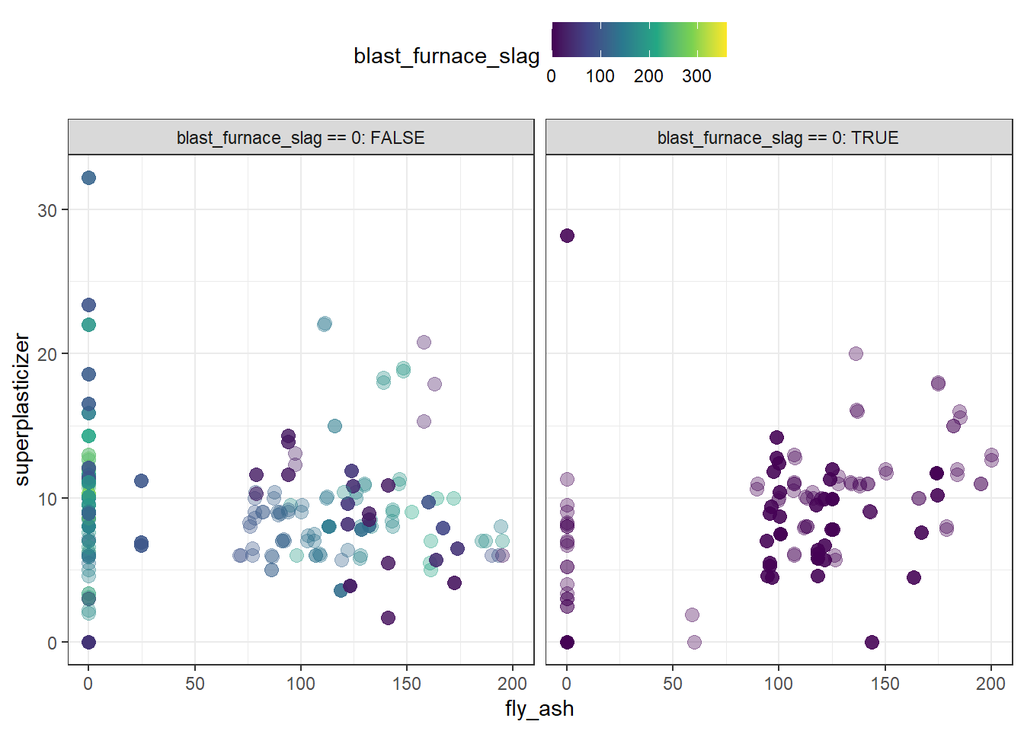

```r
my_concrete %>%
  ggplot(mapping = aes(x = fly_ash, y = superplasticizer)) +
  geom_point(mapping = aes(color = blast_furnace_slag),
             alpha = 0.35,
             size = 3) +
  facet_wrap( ~ blast_furnace_slag == 0, labeller = "label_both") +
  scale_color_viridis_c() +
  theme_bw() +
  theme(legend.position = "top")
```

Next, let’s consider the influence of `age` equaling 28.

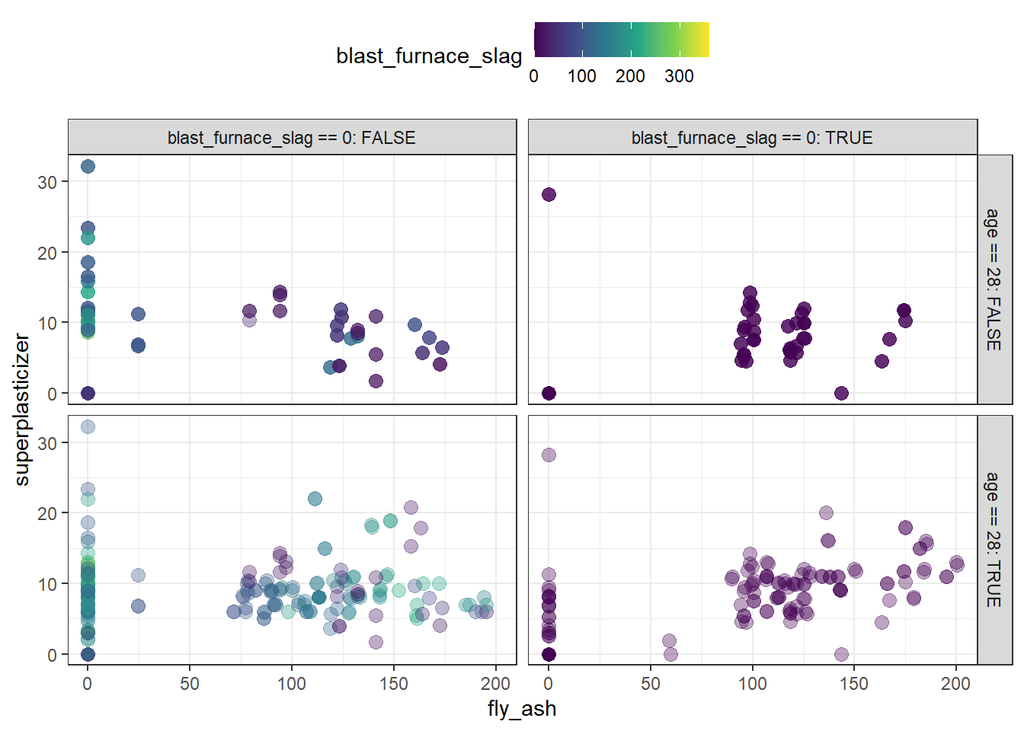

```r
my_concrete %>%
  ggplot(mapping = aes(x = fly_ash, y = superplasticizer)) +
  geom_point(mapping = aes(color = blast_furnace_slag),
             alpha = 0.35,
             size = 3) +
  facet_grid( age == 28 ~ blast_furnace_slag == 0, labeller = "label_both") +
  scale_color_viridis_c() +
  theme_bw() +
  theme(legend.position = "top")
```

Rather than continuing to make more and more scatter plots, let’s jump to a pairs plot. This style of graphic shows scatter plots for each pair of variables. The `GGally` package (an extension package to the `ggplot2` library) is used, and so you must first download and install `GGally` to run the code chunk below. By default, `GGally::ggpairs()` shows the scatter plots below the main diagonal and the correlation coefficients above the main diagonal. The main diagonal shows the *marginal* distributions with density plots by default. The pairs plot below only shows the 8 inputs.

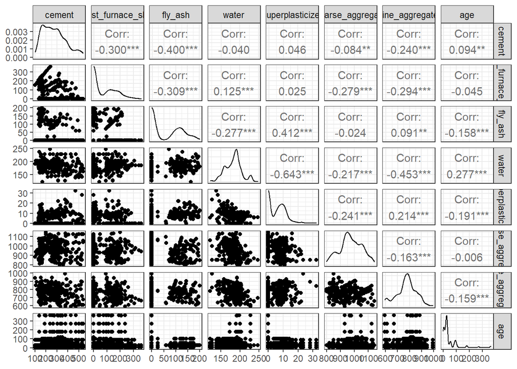

```r
my_concrete %>%
  GGally::ggpairs(columns = 1:8,
                  progress = FALSE) +
  theme_bw()
```

The pairs plot identifies a grid like structure between `age` and the other inputs! For example, a scatter plot with marker size showing the count per combination of `age` and `cement` is shown below.

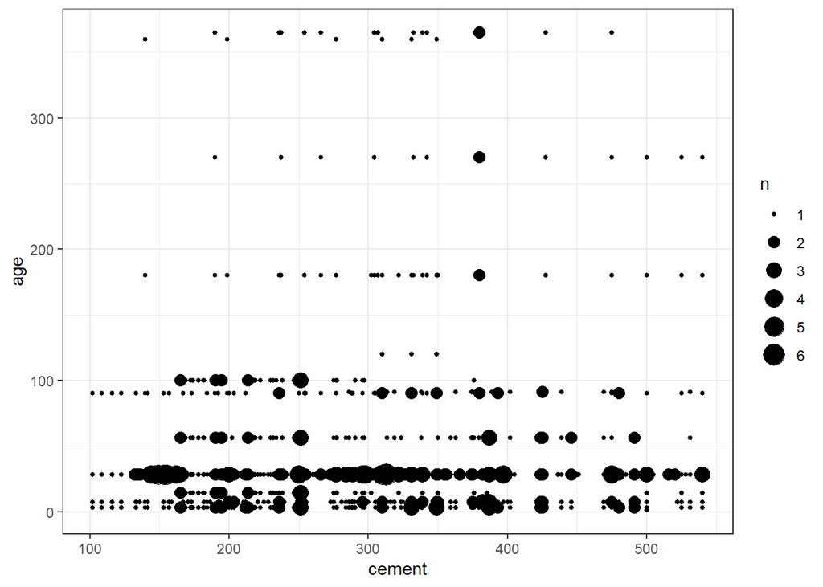

```r
my_concrete %>%
  ggplot(mapping = aes(x = cement, y = age)) +
  geom_count() +
  theme_bw()
```

We can focus just on the correlation coefficients with a **correlation plot**. The `corrplot` package provides streamlined functions dedicated to visualization correlation plots. Please download and install `corrplot` to run the code chunk below. Correlation plots are important because we must always consider if inputs are highly correlated or not **before** we train models. Correlated inputs can make interpretation difficult, impact the uncertainty in parameter estimates, and at worst cause numerical issues with the model fitting procedure. As a general rule of thumb, if inputs/features have correlation coefficients greater than 0.8 or so, we should consider approaches that are dedicated to handling highly correlated variables. As shown by the correlation plot below, it seems that we do not need to worry about such issues currently.

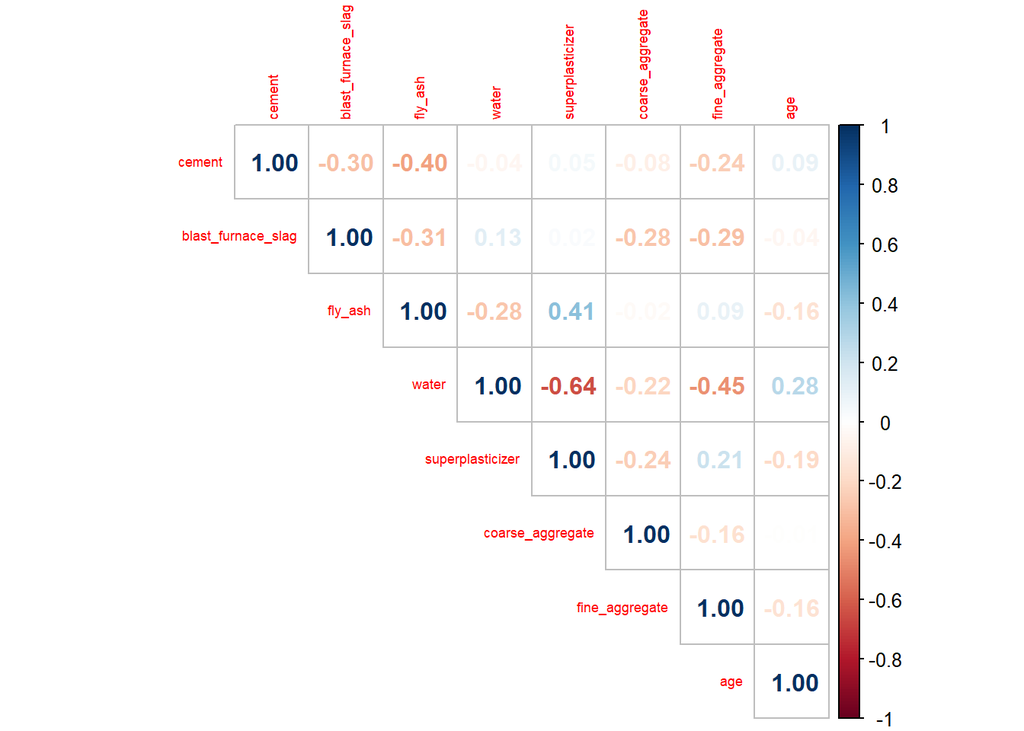

```r
my_concrete %>%
  select(-compressive_strength) %>%
  as.data.frame() %>%
  cor() %>%
  corrplot::corrplot(method = 'number', type = 'upper', tl.cex = 0.55)
```

The `corrplot` package is useful because it is so streamlined. However, sometimes we need greater control when creating correlation plots. For example, `corrplot` is difficult to use when we want to create grouped correlation plots. The code chunk below uses `corrr` (part of `tidymodels`) and `tidyr` (part of the `tidyverse`) to examine if the input correlation coefficients change based on if `blast_furnace_slag` equals zero or not. The displayed warning message tells us that a variable has zero standard deviation when `blast_furnace_slag == 0`. A warning message appears because when `blast_furnace_slag == 0`, that variable by definition has zero variation. That is why grey boxes appear in the `blast_furnace_slag == 0` facet.

```
## Warning in stats::cor(x = x, y = y, use = use, method = method): the standard
## deviation is zero
```

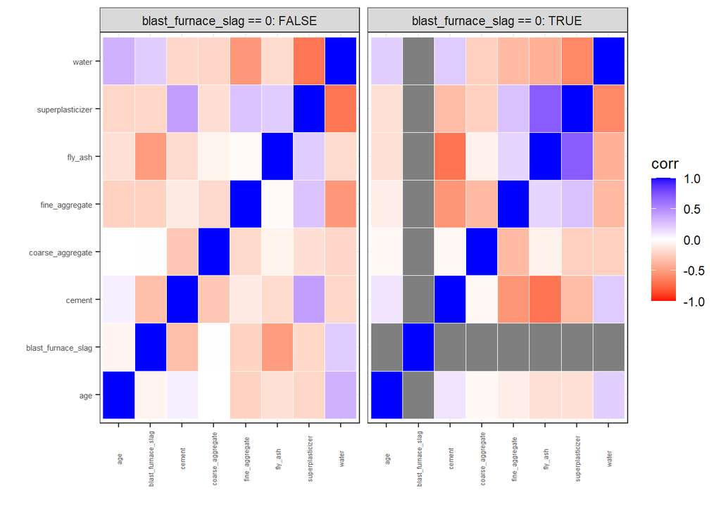

```r
my_concrete %>%
  select(-compressive_strength) %>%
  group_by(blast_furnace_slag == 0) %>%
  tidyr::nest() %>%
  mutate(cor_wf = map(data, corrr::correlate, quiet = TRUE, diagonal = 1),
         cor_lf = map(cor_wf, corrr::stretch)) %>%
  select(`blast_furnace_slag == 0`, cor_lf) %>%
  tidyr::unnest(cor_lf) %>%
  ungroup() %>%
  ggplot(mapping = aes(x = x, y = y)) +
  geom_tile(mapping = aes(fill = r),
            color = 'white') +
  facet_wrap( ~ `blast_furnace_slag == 0`, labeller = "label_both") +
  scale_fill_gradient2('corr',
                       low = 'red', mid = 'white', high = 'blue',
                       midpoint = 0,
                       limits = c(-1, 1)) +
  labs(x='', y='') +
  theme_bw() +
  theme(axis.text.x = element_text(angle=90, vjust=0.5, size=4.5),
        axis.text.y = element_text(size = 5.5))
```

Sometimes it can be useful to focus on the absolute value of the correlation coefficient. This streamlines the visualization. Furthermore, a discretized color scale can help us understand if the value is above thresholds of interest. The graphic below shows the same grouped correlation plot, but the tile fill corresponds to the correlation coefficient absolute value and the discrete color scale highlights if the correlation coefficient is above 0.8 or not. As shown below, it does not appear that we have very high correlation coefficients even when considering the grouping of `blast_furnace_slag == 0`. We could continue visualizing such groupings, but we will conclude this exploration for now.

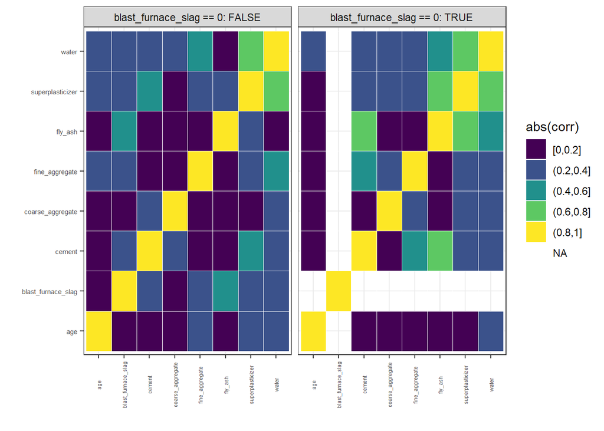

```r
my_concrete %>%
  select(-compressive_strength) %>%
  group_by(blast_furnace_slag == 0) %>%
  tidyr::nest() %>%
  mutate(cor_wf = map(data, corrr::correlate, quiet = TRUE, diagonal = 1),
         cor_lf = map(cor_wf, corrr::stretch)) %>%
  select(`blast_furnace_slag == 0`, cor_lf) %>%
  tidyr::unnest(cor_lf) %>%
  ungroup() %>%
  mutate(r_bin = cut(abs(r),
                     breaks = seq(0, 1, by = 0.2),
                     include.lowest = TRUE)) %>%
  ggplot(mapping = aes(x = x, y = y)) +
  geom_tile(mapping = aes(fill = r_bin),
            color = 'white') +
  facet_wrap( ~ `blast_furnace_slag == 0`, labeller = "label_both") +
  scale_fill_viridis_d("abs(corr)") +
  labs(x='', y='') +
  theme_bw() +
  theme(axis.text.x = element_text(angle=90, vjust=0.5, size=4.5),
        axis.text.y = element_text(size = 5.5))
```

The previous set of figures focused on the relationship between the inputs. Again, we must explore such relationships because highly correlated inputs impact our choice of models to consider. Next, we will consider the relationship between the inputs and the continuous response, `compressive_strength`. As a reminder, the histogram for the response is shown below. A rug plot is included to show the individual observations, and the *boxplot* reference quantiles (0, 0.25, 0.5, 0.75, and 1.0) are included for additional reference. The strength of a material must be positive. However, because the distribution is not “pushed up” against zero, we may not have to worry about transforming the response in this application.

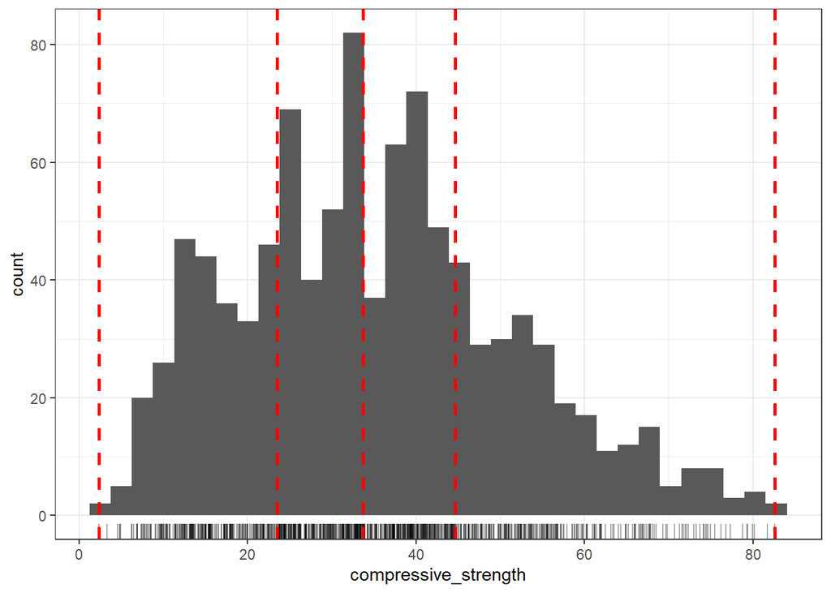

```r
my_concrete %>%
  ggplot(mapping = aes(x = compressive_strength)) +
  geom_rug(alpha = 0.33) +
  geom_histogram(bins = 33) +
  geom_vline(xintercept = quantile(my_concrete$compressive_strength),
             color = 'red', linetype = 'dashed', size = 1.) +
  theme_bw()
```

The response to input relationships are visualized with scatter plots below. Each input is associated with a separate facet. Visually, there seems to be a relationship between the strength with the `age` and `cement`.

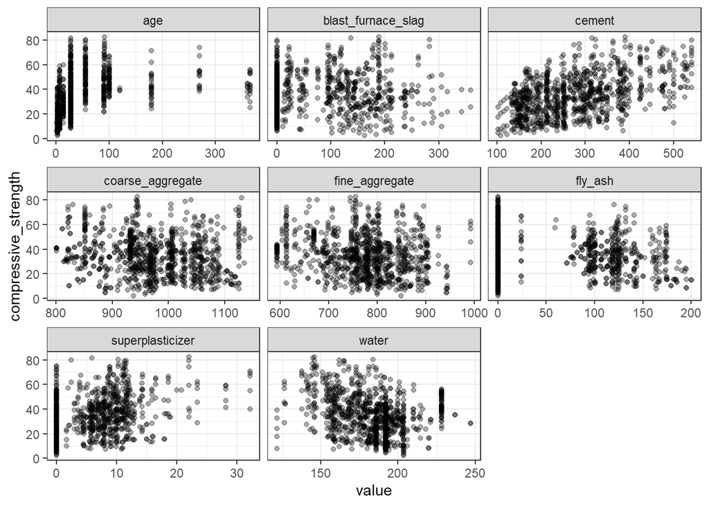

```r
my_concrete %>%
  tibble::rowid_to_column() %>%
  pivot_longer(!c("rowid", "compressive_strength")) %>%
  ggplot(mapping = aes(x = value, y = compressive_strength)) +
  geom_point(alpha = 0.33) +
  facet_wrap(~name, scales = "free_x") +
  theme_bw()
```

Since we know that `age` has relatively few unique values, let’s use **boxplots** to summarize the distribution the response for each unique value of `age`. The mean response is also summarized with it’s confidence interval as a red marker and red error bar, respectively. As we can see below, the average response increases and then appears to level off when the aging time is greater than 50. There is one age group with much higher average values than the others, but we will need models to help us understand the influence of the other variables to know if that behavior is due to `age` or not.

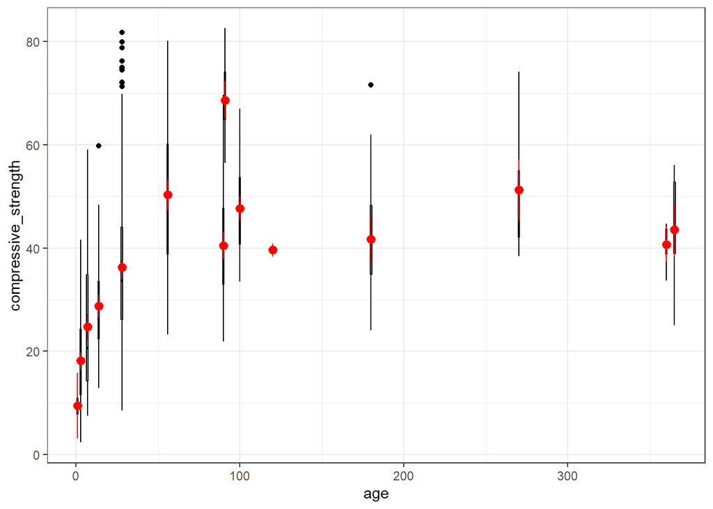

```r
my_concrete %>%
  ggplot(mapping = aes(x = age, y = compressive_strength)) +
  geom_boxplot(mapping = aes(group = age),
               fill = 'grey', color = 'black') +
  stat_summary(fun.data = 'mean_se',
               fun.args = list(mult = 2),
               color = 'red',
               mapping = aes(group = age)) +
  theme_bw()
```

The scatter plot below focuses on the relationship between the response and `cement`. The marker color corresponds to the `age` discretized into it’s quartiles.

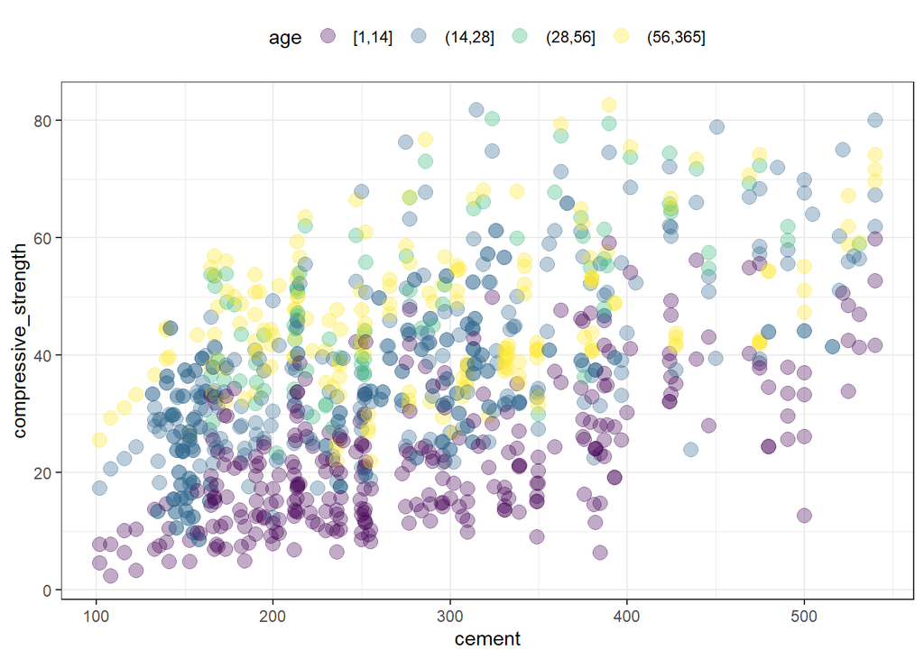

```r
my_concrete %>%
  ggplot(mapping = aes(x = cement, y = compressive_strength)) +
  geom_point(mapping = aes(color = cut(age,
                                       breaks = quantile(age),
                                       include.lowest = TRUE)),
             size = 3.5, alpha = 0.33) +
  scale_color_viridis_d("age") +
  theme_bw() +
  theme(legend.position = "top")
```

We can include a *smoother* to help identify the general trend between the two variables. Linear trends are shown below for each age group. It appears that the response increases as the `cement` value increases. The influence of `age` is to “shift” or “slide” the response value upwards, while appearing to maintain the same slope for all but the highest `age` bin.

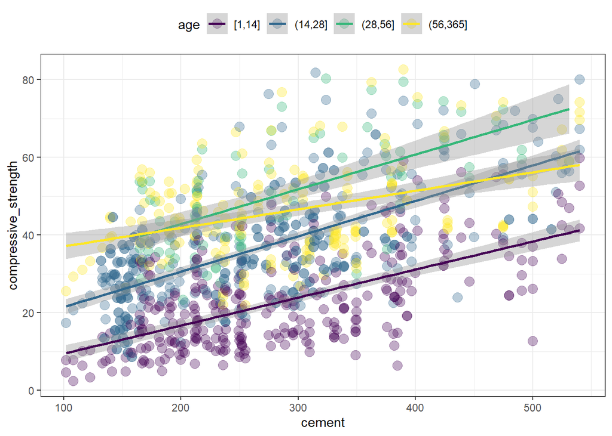

```r
my_concrete %>%
  mutate(age_bin = cut(age,
                       breaks = quantile(age),
                       include.lowest = TRUE)) %>%
  ggplot(mapping = aes(x = cement, y = compressive_strength)) +
  geom_point(mapping = aes(color = age_bin),
             size = 3.5, alpha = 0.33) +
  geom_smooth(formula = y ~ x,
              method = lm,
              mapping = aes(color = age_bin,
                            group = age_bin)) +
  scale_color_viridis_d("age") +
  theme_bw() +
  theme(legend.position = "top")
```

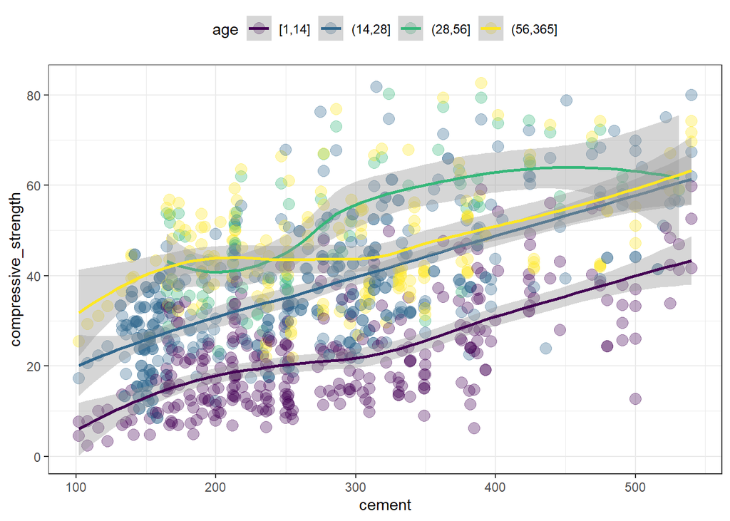

```r
my_concrete %>%
  mutate(age_bin = cut(age,
                       breaks = quantile(age),
                       include.lowest = TRUE)) %>%
  ggplot(mapping = aes(x = cement, y = compressive_strength)) +
  geom_point(mapping = aes(color = age_bin),
             size = 3.5, alpha = 0.33) +
  geom_smooth(formula = y ~ x,
              mapping = aes(color = age_bin,
                            group = age_bin)) +
  scale_color_viridis_d("age") +
  theme_bw() +
  theme(legend.position = "top")
```

### Exploration conclusion

It would be best to continue visually exploring the relationships. However, we will conclude this exercise for now. Our major findings is that several of the variables have challenging “mixture” type distributions and `age` has relatively few unique values. The mixture type distributions will complicate the analysis. The response, `compressive_strength`, appears to have a non-linear relationship with `age`. The strength appears to have a linear trend with `cement`. The slope of that relationship does not appear to be strongly influenced by `age`, but we will need to models to confirm if that is the case or not. Importantly, we have identified that the 8 inputs are not highly correlated with each other.

## Predictive modeling

We will train multiple models, ranging from simple to complex. This will allow us to understand the kinds of features required to appropriately model the trends and relationships between the inputs and response. We do not want to simply **overfit** to the training data, and so we will assess model performance via a resampling scheme. The resampling procedure will also allow us to tune *hyperparameters* which cannot be easily estimated when the models are fit.

The tmwr book in Chapter 15 used an initial train/test split, followed by 5-fold cross-validation. I prefer to work with repeated cross-validation instead of the initial train/test split approach. We will discuss the merits of such approaches throughout the course. The code chunk below defines an object which captures how the complete data set, `my_concrete`, will be resampled multiple times. Specifically, we will use 5-fold with 5-repeats. The response, `compressive_strength`, is used as a stratification variable to help make sure the *splits* roughly capture the same spread in the response. The `cv_folds` object includes columns, `id` and `id2`, that identify the splits. The `id2` columns gives the fold-id within a repeat identfied by the `id` column.

```r
set.seed(2021)
cv_folds <- vfold_cv(my_concrete, v = 5, repeats = 5, strata = compressive_strength)

cv_folds
```

```
## #  5-fold cross-validation repeated 5 times using stratification
## # A tibble: 25 x 3
##    splits            id      id2
##    <list>            <chr>   <chr>
##  1 <split [792/200]> Repeat1 Fold1
##  2 <split [792/200]> Repeat1 Fold2
##  3 <split [793/199]> Repeat1 Fold3
##  4 <split [795/197]> Repeat1 Fold4
##  5 <split [796/196]> Repeat1 Fold5
##  6 <split [792/200]> Repeat2 Fold1
##  7 <split [792/200]> Repeat2 Fold2
##  8 <split [793/199]> Repeat2 Fold3
##  9 <split [795/197]> Repeat2 Fold4
## 10 <split [796/196]> Repeat2 Fold5
## # ... with 15 more rows
```

Before training, it is best to decide how we will assess the model performance. We must consider performance metrics appropriate for a regression problem. We will compare model performance via root mean square error (RMSE), R-squared, and the mean absolute error (MAE). The RMSE and MAE focus on individual point-wise accuracy. The MAE is less influenced by extreme values (outliers). The lower the RMSE or MAE the better. The R-squared (also known as the coefficient of determination) does not consider point-wise accuracy. Instead, R-squared measures the correlation between the model prediction and the observations. R-squared is simply the square of the correlation coefficient between the model prediction and the observed value. It is between 0 and 1; the closer the value to 1 the better the model is performing. It is important to consider multiple performance metrics when comparing models. Each metric provides a slightly different interpretation of the behavior. Using multiple performance metrics allows us consider potential trade-offs when we ultimately select a model or models to focus on.

The code chunk below defines the metric set we will use to assess performance.

```r
my_metrics <- metric_set(rmse, rsq, mae)
```

### Linear methods

Although it is common to think of preprocessing as a separate action from models, we should view preprocessing as an integral aspect of the type of models we train. Afterall, using a different set of preprocessing actions may yield different behavior and thus performance from the same type of model. In this section, we will train **linear models** but with different types of *predictors* or *features* derived from the inputs. The features will be created within a recipe object to allow preprocessing actions such as **centering** and **scaling** to be performed within each resample fold during training.

#### Linear additive relationships

We will start with a simple model with linear additive features. This model cannot handle non-linear trends between the response and inputs, and cannot capture any type of interaction between inputs. Our exploratory data analysis (EDA) revealed non-linearities are present between the response and `age`. Thus, we should expect the linear additive model to perform poorly in this application. However, I always recommend starting with this model because it is easy to fit and train, simple to interpret, and serves as a useful benchmark case. We can judge the performance of more advanced models based on the improvement relative to this simple model.

In the `tidymodels` framework, we will first define the linear model *engine* and specification we wish to use.

```r
lm_spec <- linear_reg() %>%
  set_engine("lm")
```

Next, let’s create a recipe object which standardizes the inputs and produces the additive features.

```r
bp_stan <- recipe(compressive_strength ~ ., data = my_concrete) %>%
  step_center(all_predictors()) %>%
  step_scale(all_predictors())
```

We can always check we are getting the features we want by “prepping” the recipe and “baking” it into the data. The code chunk below preps, bakes, and displays the names of the columns of the standardized training set.

```r
check_stan_df <- bp_stan %>%
  prep(training = my_concrete, retain = TRUE) %>%
  bake(new_data = NULL)

check_stan_df %>% names()
```

```
## [1] "cement"               "blast_furnace_slag"   "fly_ash"
## [4] "water"                "superplasticizer"     "coarse_aggregate"
## [7] "fine_aggregate"       "age"                  "compressive_strength"
```

The code chunk below summarizes the distributions of the standardized features on the entire training set with a boxplot. Notice that the boxplots roughly cover the same scale because the inputs have been standardized.

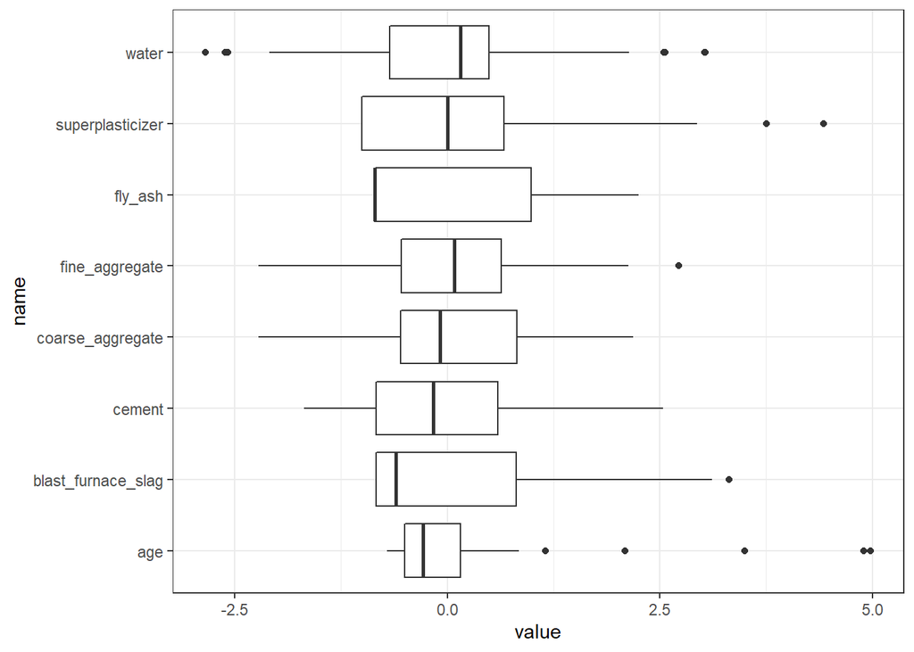

```r
check_stan_df %>%
  tibble::rowid_to_column() %>%
  pivot_longer(!c("rowid", "compressive_strength")) %>%
  ggplot(mapping = aes(y = name, x = value)) +
  geom_boxplot() +
  theme_bw()
```

As a comparison, the graphic below shows the boxplot for the inputs in their *raw* scales.

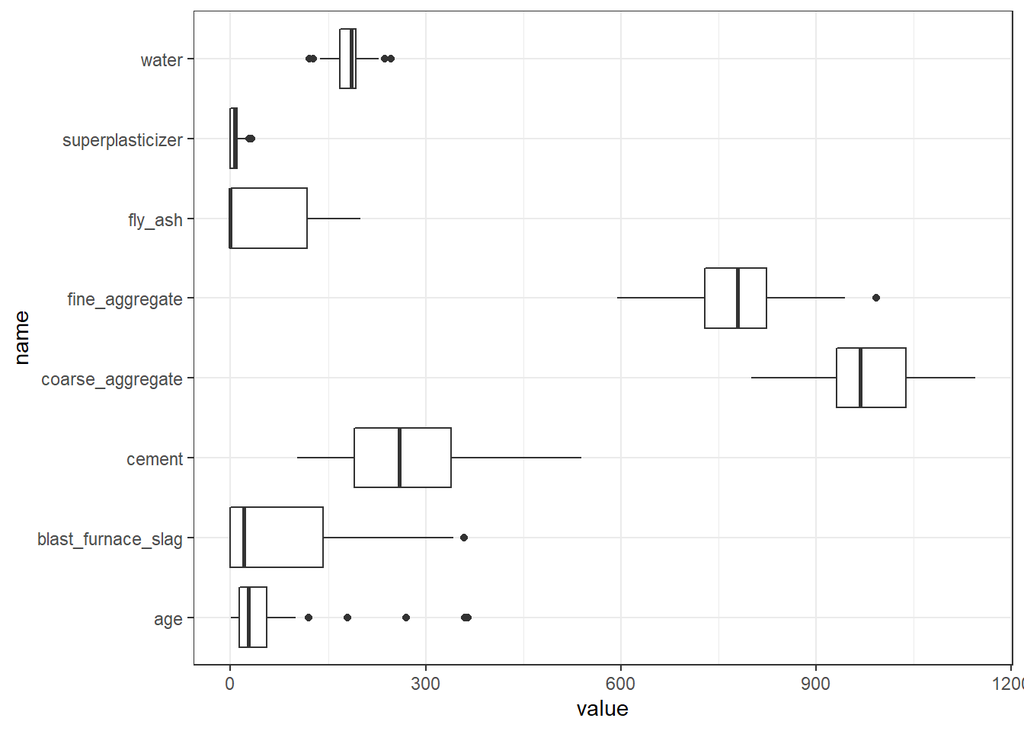

```r
my_concrete %>%
  tibble::rowid_to_column() %>%
  pivot_longer(!c("rowid", "compressive_strength")) %>%
  ggplot(mapping = aes(y = name, x = value)) +
  geom_boxplot() +
  theme_bw()
```

Before training the model we will define a **workflow** which understands that our complete model consists of a set of preprocessing steps and a specific model type.

```r
lm_add_wflow <- workflow() %>%
  add_model(lm_spec) %>%
  add_recipe(bp_stan)
```

The workflow is an object that understands the steps or *algorithm* required. Printing `lm_add_wflow` to the screen describes all of the actions that the model will perform.

```r
lm_add_wflow
```

```
## == Workflow ====================================================================
## Preprocessor: Recipe
## Model: linear_reg()
##
## -- Preprocessor ----------------------------------------------------------------
## 2 Recipe Steps
##
## * step_center()
## * step_scale()
##
## -- Model -----------------------------------------------------------------------
## Linear Regression Model Specification (regression)
##
## Computational engine: lm
```

We will now fit the model and assess the performance using the repeated cross-validation strategy. The code chunk below uses the `fit_resamples()` function to fit (train) and assess the performance. It is important to note that the `my_concrete` object is provided to `fit_resamples()` **not** the `check_stan_df` object. The `check_stan_df` data set has the standardization already applied (or “baked” in to follow the `tidymodels` love of puns). We want the preprocessing steps to be applied **within** each resample fold. The workflow, `lm_add_wflow`, *knows* the preprocessing actions to take and will apply the standardization based on each fold’s specific training set. Thus, our **complete** model of preprocessing and model type will correctly account for the potential differences between the training and test set! We will discuss why it is important to apply the preprocessing within each fold near the end of the semester when we discuss PCA in greater detail.

```r
lm_add_res <- lm_add_wflow %>%
  fit_resamples(cv_folds,
                metrics = my_metrics)
```

The `lm_add_res` object stores the results associated with each resample split.

```r
lm_add_res
```

```
## # Resampling results
## # 5-fold cross-validation repeated 5 times using stratification
## # A tibble: 25 x 5
##    splits            id      id2   .metrics         .notes
##    <list>            <chr>   <chr> <list>           <list>
##  1 <split [792/200]> Repeat1 Fold1 <tibble [3 x 4]> <tibble [0 x 1]>
##  2 <split [792/200]> Repeat1 Fold2 <tibble [3 x 4]> <tibble [0 x 1]>
##  3 <split [793/199]> Repeat1 Fold3 <tibble [3 x 4]> <tibble [0 x 1]>
##  4 <split [795/197]> Repeat1 Fold4 <tibble [3 x 4]> <tibble [0 x 1]>
##  5 <split [796/196]> Repeat1 Fold5 <tibble [3 x 4]> <tibble [0 x 1]>
##  6 <split [792/200]> Repeat2 Fold1 <tibble [3 x 4]> <tibble [0 x 1]>
##  7 <split [792/200]> Repeat2 Fold2 <tibble [3 x 4]> <tibble [0 x 1]>
##  8 <split [793/199]> Repeat2 Fold3 <tibble [3 x 4]> <tibble [0 x 1]>
##  9 <split [795/197]> Repeat2 Fold4 <tibble [3 x 4]> <tibble [0 x 1]>
## 10 <split [796/196]> Repeat2 Fold5 <tibble [3 x 4]> <tibble [0 x 1]>
## # ... with 15 more rows
```

We can use the helper function `collect_metrics()` to summarize performance across all splits. Notice that the `n` column equals 25 for all three metrics. This is because we used 5 fold with 5 repeats and thus there are 25 observations of each performance metric.

```r
lm_add_res %>% collect_metrics()
```

```
## # A tibble: 3 x 6
##   .metric .estimator   mean     n std_err .config
##   <chr>   <chr>       <dbl> <int>   <dbl> <chr>
## 1 mae     standard    8.16     25 0.0793  Preprocessor1_Model1
## 2 rmse    standard   10.3      25 0.100   Preprocessor1_Model1
## 3 rsq     standard    0.603    25 0.00693 Preprocessor1_Model1
```

By default the `collect_metrics()` function returns the average and standard error associated with each performance metric. We can return the performance metric associated with each split if we prefer, as shown in the code chunk below. Each split (a fold within a repeat) has estimates for the three metrics we specified earlier. It is **very** important to remember that these metrics are calculated on the **hold-out** set associated with each split. Cross-validation produces different training and test sets per fold. Within a fold the model is trained on the training set, and assess/evaluated/tested on the hold-out set. Sometimes the fold hold-out set is referred to as the **validation set**, to highlight we are validating performance. Cross-validation returns as many performance estimates as number of splits. The previous code chunk summarized the behavior across the splits to provide an estimate to the average performance on new data.

```r
lm_add_res %>% collect_metrics(summarize = FALSE)
```

```
## # A tibble: 75 x 6
##    id      id2   .metric .estimator .estimate .config
##    <chr>   <chr> <chr>   <chr>          <dbl> <chr>
##  1 Repeat1 Fold1 rmse    standard      10.1   Preprocessor1_Model1
##  2 Repeat1 Fold1 rsq     standard       0.645 Preprocessor1_Model1
##  3 Repeat1 Fold1 mae     standard       8.14  Preprocessor1_Model1
##  4 Repeat1 Fold2 rmse    standard      10.5   Preprocessor1_Model1
##  5 Repeat1 Fold2 rsq     standard       0.554 Preprocessor1_Model1
##  6 Repeat1 Fold2 mae     standard       8.37  Preprocessor1_Model1
##  7 Repeat1 Fold3 rmse    standard      11.0   Preprocessor1_Model1
##  8 Repeat1 Fold3 rsq     standard       0.544 Preprocessor1_Model1
##  9 Repeat1 Fold3 mae     standard       8.51  Preprocessor1_Model1
## 10 Repeat1 Fold4 rmse    standard      10.6   Preprocessor1_Model1
## # ... with 65 more rows
```

We have trained and assessed performance for our first model! But that is just a single model. We can now consider other formulations and types of features to see if we can improve performance.

#### All pair-wise interactions

Our previous model consisted of additive features. Let’s now consider a model that allows all pairs of inputs to interact with each other. We will still standardize the inputs before creating the pair-wise interactions. The code chunk below creates a new recipe object by building from the standardization recipe created previously.

```r
bp_pairs <- bp_stan %>%
  step_interact( ~ all_predictors():all_predictors())
```

Let’s prep and bake the recipe to again confirm the features are being created as we expect them to be. The code chunk below displays the number of columns to the screen for the all-pair wise interaction data set.

```r
check_stan_pairs_df <- bp_pairs %>%
  prep(training = my_concrete, retain = TRUE) %>%
  bake(new_data = NULL)

check_stan_pairs_df %>% dim()
```

```
## [1] 992  37
```

There are 37 columns in the data set! The code chunk below displays the names of the features. The first set of features are the **main-effect** terms, the original inputs. An *interaction* is a **multiplication** between inputs/features. An interaction feature is named in `tidymodels` to “read” as saying “variable multiplied by variable”. Notice that after the response name, `compressive_strength`, the additional names include `_x_`. That character pattern represents a multiplication or “times”, $\times$. The name `cement_x_water` therefore tells us this feature corresponds to the product of `cement` times `water`.

```r
check_stan_pairs_df %>% names()
```

```
##  [1] "cement"
##  [2] "blast_furnace_slag"
##  [3] "fly_ash"
##  [4] "water"
##  [5] "superplasticizer"
##  [6] "coarse_aggregate"
##  [7] "fine_aggregate"
##  [8] "age"
##  [9] "compressive_strength"
## [10] "cement_x_blast_furnace_slag"
## [11] "cement_x_fly_ash"
## [12] "cement_x_water"
## [13] "cement_x_superplasticizer"
## [14] "cement_x_coarse_aggregate"
## [15] "cement_x_fine_aggregate"
```

[output cut: 22 more lines]

It is important to note that when we are working with `tidymodels` we do not have to “bake” in the recipe. We are applying the preprocessing and feature creation steps to help show what the features will be when the model is trained. In our application the workflow object and the `fit_resamples()` function will take care those steps for us!

Let’s create the workflow for the model with all pair-wise interactions. Notice that the linear model specification is the same as `lm_add_wflow`. We changed the kinds of features the model will work with.

```r
lm_pairs_wflow <- workflow() %>%
  add_model(lm_spec) %>%
  add_recipe(bp_pairs)
```

The model is trained and assessed in the code chunk below.

```r
lm_pairs_res <- lm_pairs_wflow %>%
  fit_resamples(cv_folds,
                metrics = my_metrics)
```

The cross-validation summarized performance metrics for the all pair-wise interaction model are printed to the screen below.

```r
lm_pairs_res %>% collect_metrics()
```

```
## # A tibble: 3 x 6
##   .metric .estimator  mean     n std_err .config
##   <chr>   <chr>      <dbl> <int>   <dbl> <chr>
## 1 mae     standard   6.78     25 0.0687  Preprocessor1_Model1
## 2 rmse    standard   8.56     25 0.0962  Preprocessor1_Model1
## 3 rsq     standard   0.725    25 0.00443 Preprocessor1_Model1
```

#### All triplet interactions

The previous model’s features included muliplications between two inputs. We could also consider the product of three inputs! This type of model represents that the trend between the response and an input depends on two other inputs.

The code chunk below creates the recipe for the triplet interaction starting from the standardized inputs. The triplet interaction product will include all **main-effect** and pair-wise interaction terms.

```r
bp_trips <- bp_stan %>%
  step_interact( ~ all_predictors():all_predictors():all_predictors())
```

Let’s bake-in this recipe to see just how many features are present in a model which includes up to all triplet interactions. The code chunk below prints the number of features (after the response is removed) to the screen. Even though our application has 8 inputs, allowing all triplet interactions creates a model with 92 features!

```r
bp_trips %>%
  prep(training = my_concrete, retain = TRUE) %>%
  bake(new_data = NULL) %>%
  select(-compressive_strength) %>%
  ncol()
```

```
## [1] 92
```

The triplet interaction model workflow is created below.

```r
lm_trips_wflow <- workflow() %>%
  add_model(lm_spec) %>%
  add_recipe(bp_trips)
```

The model is trained and assessed below.

```r
lm_trips_res <- lm_trips_wflow %>%
  fit_resamples(cv_folds,
                metrics = my_metrics)
```

We will examine the triplet interaction model performance when we compare all linear methods later on.

#### Response surface methods

Response surface methods (RSM) are classic statistical models historically used to optimize manufacturing and process control systems. Although RSMs have their own name and terminology, they are simply linear models with interactions and polynomial features. Thus, we can fit response surfaces using the exact same techniques we used previously. We just need to include polynomial features in the recipe. We will use response surfaces as our first attempt to capture non-linear relationships between the response and the inputs. We saw in the EDA that the response appears non-linearly related to `age` and so we will use polynomial features to try and represent that relationship.

The code chunk below creates the recipe for a quadratic response surface and a cubic response surface. The quadratic model includes all pair-wise interactions, and the cubic model includes all triplet interactions.

```r
bp_rsm_2 <- bp_stan %>%
  step_poly(all_predictors(), degree = 2,
            options = list(raw = TRUE)) %>%
  step_interact(~ends_with("_poly_1"):ends_with("_poly_1"))

bp_rsm_3 <- bp_stan %>%
  step_poly(all_predictors(), degree = 3,
            options = list(raw = TRUE)) %>%
  step_interact(~ends_with("_poly_1"):ends_with("_poly_1"):ends_with("_poly_1"))
```

The RSM workflows are created below.

```r
rsm_2_wflow <- workflow() %>%
  add_model(lm_spec) %>%
  add_recipe(bp_rsm_2)

rsm_3_wflow <- workflow() %>%
  add_model(lm_spec) %>%
  add_recipe(bp_rsm_3)
```

The RSMs are trained and assessed in the code chunk below.

```r
rsm_2_res <- rsm_2_wflow %>%
  fit_resamples(cv_folds,
                metrics = my_metrics)

rsm_3_res <- rsm_3_wflow %>%
  fit_resamples(cv_folds,
                metrics = my_metrics)
```

#### Linear methods comparison

Let’s now compare the performance of the models we have trained so far. The performance metrics within each resample fold are combined into a single data in the code chunk below.

```r
all_cv_results <- lm_add_res %>% collect_metrics(summarize = FALSE) %>%
  mutate(wflow_id = "lm add") %>%
  bind_rows(lm_pairs_res %>% collect_metrics(summarize = FALSE) %>%
              mutate(wflow_id = "lm pairs")) %>%
  bind_rows(lm_trips_res %>% collect_metrics(summarize = FALSE) %>%
              mutate(wflow_id = "lm trips")) %>%
  bind_rows(rsm_2_res %>% collect_metrics(summarize = FALSE) %>%
              mutate(wflow_id = "quad rsm")) %>%
  bind_rows(rsm_3_res %>% collect_metrics(summarize = FALSE) %>%
              mutate(wflow_id = "cubic rsm"))
```

The model performance within each repeat fold, summarized within each repeat, and summarized all resamples are shown in the figure below. The black markers show the performance metric value in a single repeat-fold. The blue marker and error bar show the repeat averaged and $\pm$ 1 standard error interval performance metric. The red marker and error bar show the cross-validation averaged and $\pm$ 1 standard error interval across all resamples. The axis is ordered to reflect the model order of increasing performance and complexity.

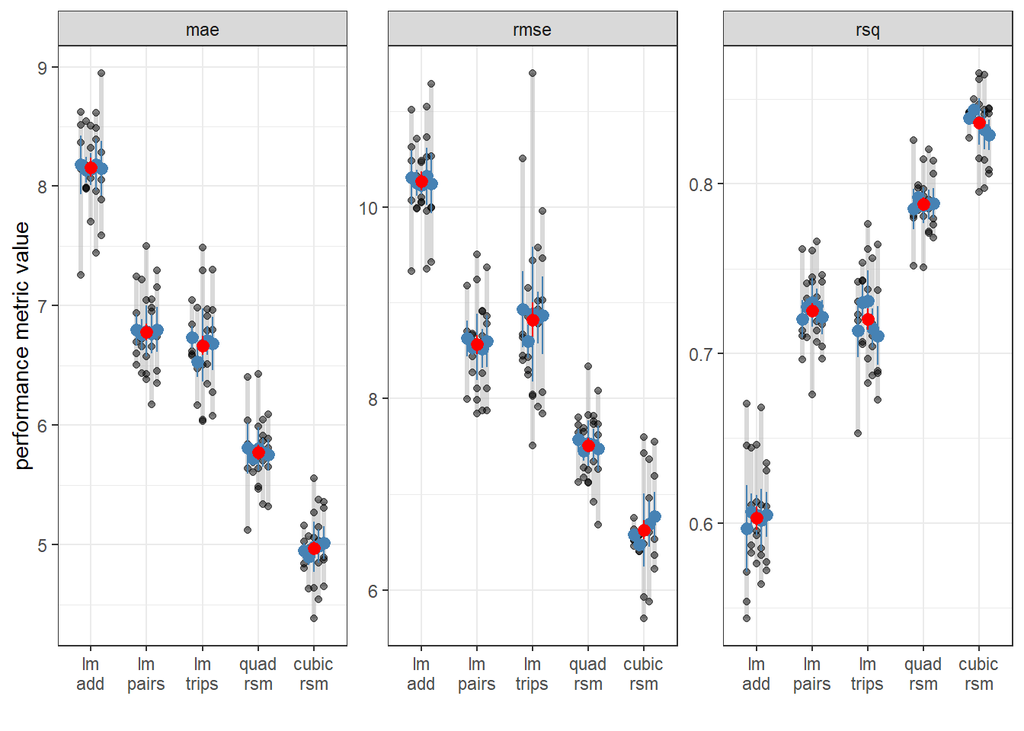

```r
all_cv_results %>%
  mutate(wflow_id = stringr::str_replace(wflow_id, " ", "\n")) %>%
  mutate(wflow_id = factor(wflow_id,
                           levels = c("lm\nadd", "lm\npairs", "lm\ntrips",
                                      "quad\nrsm", "cubic\nrsm"))) %>%
  ggplot(mapping = aes(x = wflow_id, y = .estimate)) +
  stat_summary(mapping = aes(group = interaction(wflow_id, id)),
               position = position_dodge(0.45),
               fun.min = min, fun.max = max,
               geom = 'linerange',
               color = 'grey70', size = 1.1, alpha = 0.5) +
  geom_point(mapping = aes(group = interaction(wflow_id, id)),
             position = position_dodge(0.45),
             alpha = 0.5) +
  stat_summary(mapping = aes(group = interaction(wflow_id, id)),
               position = position_dodge(0.45),
               fun.data = 'mean_se',
               fun.args = list(mult = 1),
               color = 'steelblue') +
  stat_summary(mapping = aes(group = wflow_id),
               fun.data = 'mean_se',
               fun.args = list(mult = 1),
               color = 'red') +
  facet_wrap(~.metric, scales = "free_y", nrow = 1) +
  labs(x = '', y = 'performance metric value') +
  theme_bw()
```

All three performance metrics yield consistent behavior. The cubic RSM has the best performance, followed by the quadratic RSM, then the interaction models, and lastly the linear additive features model. Note that the quadratic RSM out-performs the triplet interaction model. This represents that the non-linear features are more important than the triplet interactions since the quadratic RSM does not include triplet interactions. The cubic RSM is the most complex model, since all other models we have tried are subsets of the cubic RSM. However, that additional complexity is worth it! The most complex model tried so far not only out performs the others, but we are rather confident in it being better than the others!

The above figure is rather busy and can be difficult to interpret if you are not used to working with repeated cross-validation. A streamlined figure is one which focuses just on the overall resampled averaged performance. The code chunk below first assembles the resampled averaged results together and then visualizes the average, $\pm$ 2 standard error interval, and $\pm$ 1 standard error interval on the average for each model.

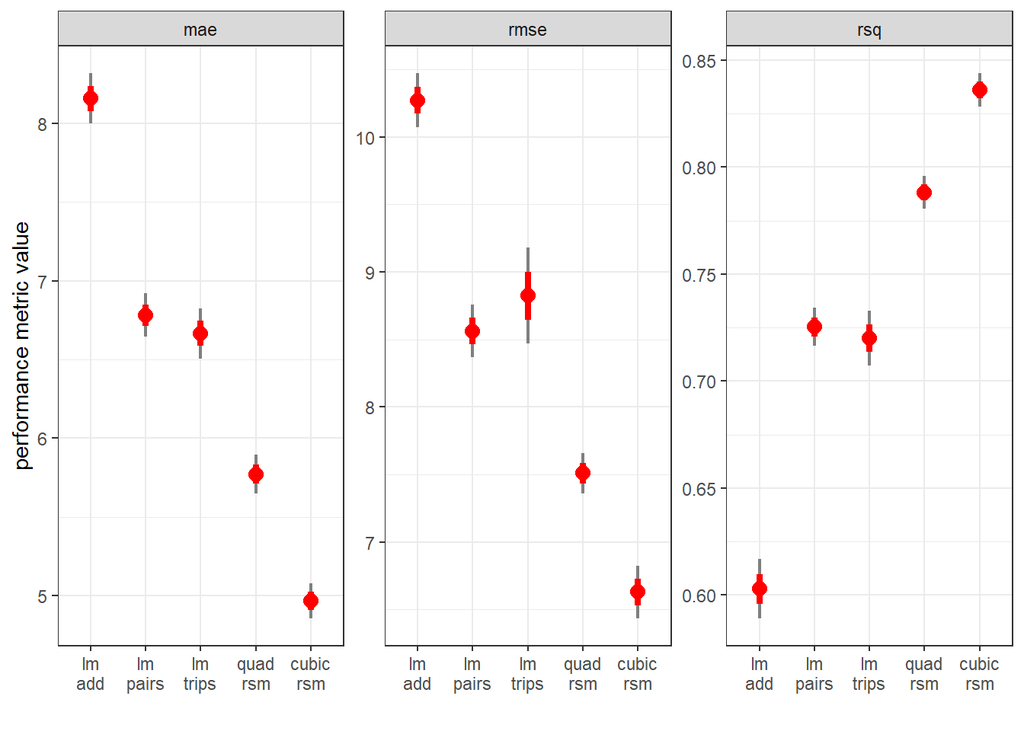

```r
all_cv_summaries <- lm_add_res %>% collect_metrics(summarize = TRUE) %>%
  mutate(wflow_id = "lm add") %>%
  bind_rows(lm_pairs_res %>% collect_metrics(summarize = TRUE) %>%
              mutate(wflow_id = "lm pairs")) %>%
  bind_rows(lm_trips_res %>% collect_metrics(summarize = TRUE) %>%
              mutate(wflow_id = "lm trips")) %>%
  bind_rows(rsm_2_res %>% collect_metrics(summarize = TRUE) %>%
              mutate(wflow_id = "quad rsm")) %>%
  bind_rows(rsm_3_res %>% collect_metrics(summarize = TRUE) %>%
              mutate(wflow_id = "cubic rsm"))

all_cv_summaries %>%
  mutate(wflow_id = stringr::str_replace(wflow_id, " ", "\n")) %>%
  mutate(wflow_id = factor(wflow_id,
                           levels = c("lm\nadd", "lm\npairs", "lm\ntrips",
                                      "quad\nrsm", "cubic\nrsm"))) %>%
  ggplot(mapping = aes(x = wflow_id)) +
  geom_linerange(mapping = aes(ymin = mean - 2*std_err,
                               ymax = mean + 2*std_err,
                               group = interaction(.metric, wflow_id)),
                 color = 'grey50', size = 0.75) +
  geom_linerange(mapping = aes(ymin = mean - 1*std_err,
                               ymax = mean + 1*std_err,
                               group = interaction(.metric, wflow_id)),
                 color = 'red', size = 1.45) +
  geom_point(mapping = aes(y = mean),
             color = 'red', size = 3.1) +
  facet_wrap(~.metric, scales = "free_y", nrow = 1) +
  labs(x = '', y = 'performance metric value') +
  theme_bw()
```

In addition to the performance metric summary values, it is also important to consider the model-to-model correlation. For example, if one model performs well within a particular fold do all models perform well in that fold? Such questions are important to consider when identifying the best model. The figure below shows a correlation plot between the model performance across all resamples. We focus only on R-squared below to simplify the visualization. Interestingly, the correlation between models is not all that high in this application.

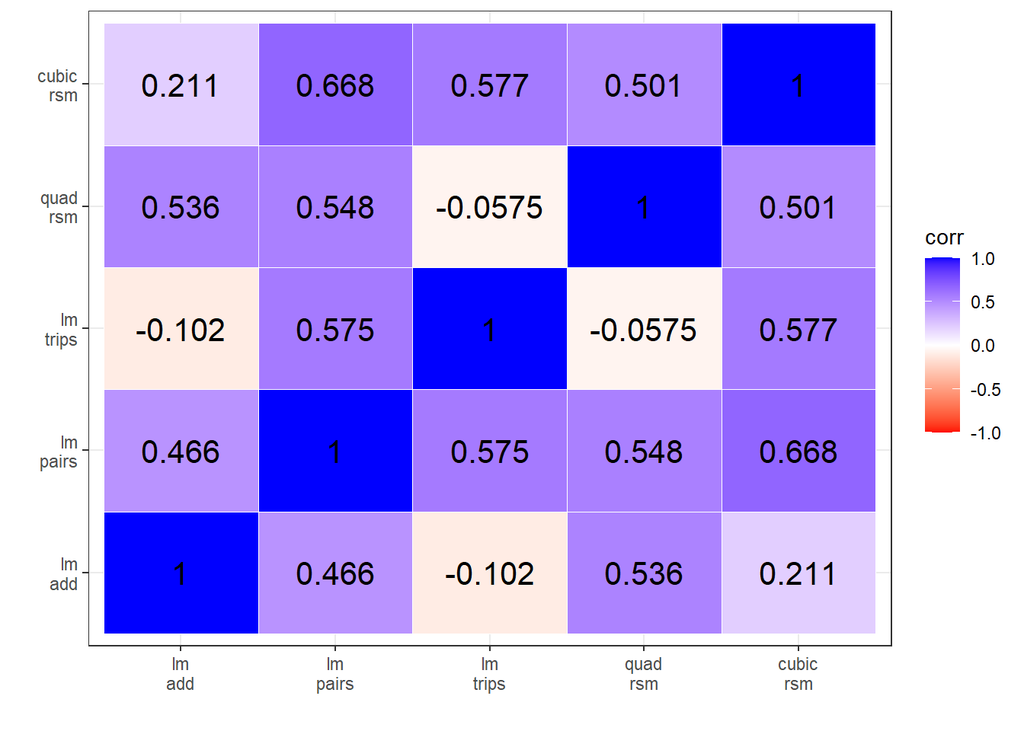

```r
all_cv_results %>%
  mutate(wflow_id = stringr::str_replace(wflow_id, " ", "\n")) %>%
  filter(.metric == 'rsq') %>%
  select(wflow_id, .estimate, id, id2) %>%
  pivot_wider(id_cols = c("id", "id2"),
              names_from = 'wflow_id', values_from = '.estimate') %>%
  select(-id, -id2) %>%
  corrr::correlate(quiet = TRUE, diagonal = 1) %>%
  corrr::stretch() %>%
  mutate(x = factor(x,
                    levels = c("lm\nadd", "lm\npairs", "lm\ntrips",
                                      "quad\nrsm", "cubic\nrsm")),
         y = factor(y,
                    levels = c("lm\nadd", "lm\npairs", "lm\ntrips",
                                      "quad\nrsm", "cubic\nrsm"))) %>%
  ggplot(mapping = aes(x = x, y = y)) +
  geom_tile(mapping = aes(fill = r),
            color = 'white') +
  geom_text(mapping = aes(label = signif(r, 3)),
            color = 'black', size = 5.5) +
  scale_fill_gradient2('corr',
                       low = 'red', mid = 'white', high = 'blue',
                       midpoint = 0,
                       limits = c(-1, 1)) +
  labs(x='', y='') +
  theme_bw()
```

#### Penalized regression - Elastic net

The cubic RSM is the most complex model we have tried so far, because it has more features than any other model. It also “contains” all other models. Even though we have seen the cubic RSM is the best performing model so far, are all features truly necessary? What are the minimum set of features required to maintain the performance of the cubic RSM? Or, put another way which features can be “turned off”?

Penalized or **regularized** regression models attempt to answer these questions. We will discuss how the penalty works and how to interpret it later in the semester. For now we will focus on training the model and **tuning** the hyperparameters that define how the model is fit. We will use the **elastic net** model from the `glmnet` package, and so you must have downloaded and installed `glmnet` to run the following examples.  
Elastic net consists of two tuning parameters. The first is the *penalty* factor (referred to as lambda by the `glmnet` authors), which controls the strength of the penalty term. Stronger penalties will turn off more features and can ultimately remove all trends in the model if allowed. The second is the *mixture* fraction (referred to as alpha by the `glmnet` authors) which is a weighting term between two types of penalties. One penalty (known as ridge) is useful for computational reasons, while the other (known as lasso) is the *model selection* penalty which forces unimportant features to zero.

`tidymodels` includes default bounds on the tuning parameters. For example the bounds on the penalty factor are:

```r
penalty()
```

```
## Amount of Regularization (quantitative)
## Transformer:  log-10
## Range (transformed scale): [-10, 0]
```

The default bounds on the mixing fraction are shown below.

```r
mixture()
```

```
## Proportion of lasso Penalty (quantitative)
## Range: [0, 1]
```

We do not know the best values of the tuning parameters up front. We will use a simple approach to tune the model by defining a search grid. We will create combinations of the two tuning parameters, train and assess the model for each combination using resampling. We will then select the tuning parameter values that give the best performance averaged over the resamples. In this way, we are essentially treating each tuning parameter combination *set* as a separate model.

We can create a search grid using the default bounds, but instead let’s modify the bounds as shown below.

```r
my_lambda <- penalty(range = c(-10.5, 2), trans = log_trans())

my_alpha <- mixture(range = c(0.1, 1.0))
```

We will use a search grid consisting of 75 unique penalty values and 5 values for the mixing fraction. The glimpse printed to the screen below shows that we are therefore trying $75\times5=375$ combinations of the two parameters. We are essentially training and assessing 375 separate models even though all models are the same type (elastic net) and have the same set of features.

```r
enet_grid <- grid_regular(my_lambda, my_alpha,
                          levels = c(penalty = 75, mixture = 5))

enet_grid %>% glimpse()
```

```
## Rows: 375
## Columns: 2
## $ penalty <dbl> 2.753645e-05, 3.260382e-05, 3.860371e-05, 4.570772e-05, 5.4119~
## $ mixture <dbl> 0.1, 0.1, 0.1, 0.1, 0.1, 0.1, 0.1, 0.1, 0.1, 0.1, 0.1, 0.1, 0.~
```

The elastic net model is defined in the code chunk below. The “translation” from `tidymodels` to the `glmnet` is also printed to the screen for your reference. You do not need to concentrate on the `glmnet()` call early in the semester. We will learn about `glmnet` later in the course. This is provided for your reference so you can come back to it later on.

```r
enet_spec <- linear_reg(penalty = tune(), mixture = tune()) %>%
  set_engine("glmnet",
             # glmnet specific options
             intercept = TRUE, standardize.response = TRUE, standardize = TRUE,
             path_values = exp(seq(-10.5, 2, length.out = 75)))

enet_spec %>% translate()
```

```
## Linear Regression Model Specification (regression)
##
## Main Arguments:
##   penalty = tune()
##   mixture = tune()
##
## Engine-Specific Arguments:
##   intercept = TRUE
##   standardize.response = TRUE
##   standardize = TRUE
##
## Computational engine: glmnet
##
## Model fit template:
## glmnet::glmnet(x = missing_arg(), y = missing_arg(), weights = missing_arg(),
##     lambda = exp(seq(-10.5, 2, length.out = 75)), alpha = tune(),
##     intercept = TRUE, standardize.response = TRUE, standardize = TRUE,
##     family = "gaussian")
```

The elastic net workflow is defined below. Notice that the cubic RSM recipe is included. This means we will use a regularized regression model (elastic net) with all triplet interactions, quadratic, and cubic polynomials. We are free to use other features, the exact feature choice depends on the application. What matters for this application is we know that this model has over 100 features!

```r
enet_wflow <- workflow() %>%
  add_model(enet_spec) %>%
  add_recipe(bp_rsm_3)
```

Before we train and assess the elastic net model, let’s get some intuition for what it’s doing. The code chunk below fits a pure lasso model to the entire data set and examines how the penalty term impacts the coefficients. The penalty (referred to as lambda by `glmnet`) increases left to right in the figure below. Each curve corresponds to the coefficient value associated with a feature. The left hand side has the smallest penalty value and the right hand side has the largest penalty. The numbers on the upper x-axis correspond to the number of non-zero coefficients. As the penalty increases more and more features are “turned off”, as represented by the number of non-zero coefficients decreasing left-to-right. Large penalty values are capable of turning off all but the most essential features!

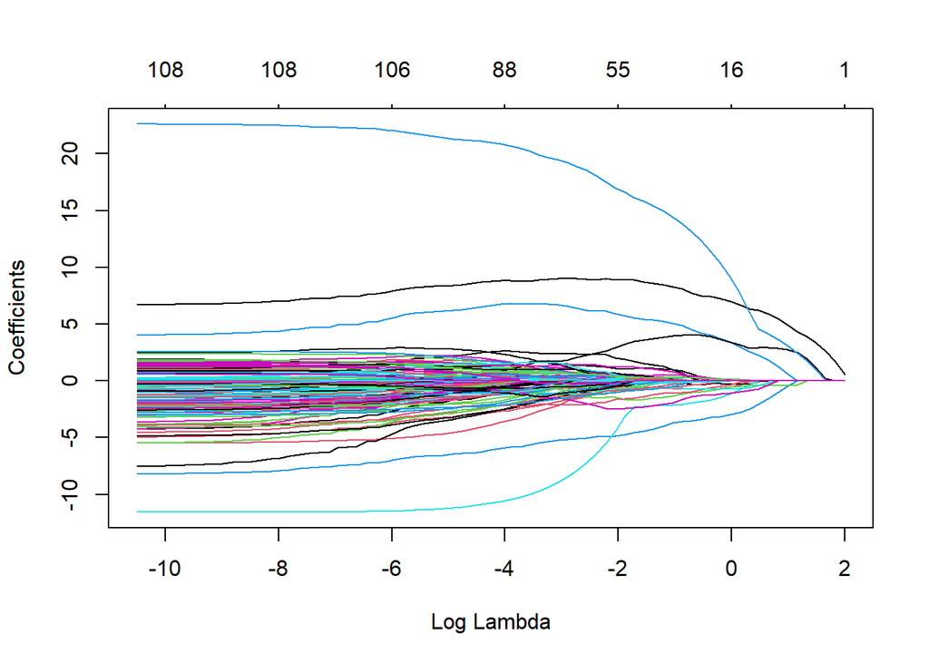

```r
lasso_fit <- enet_wflow %>%
  update_model(linear_reg(penalty = 0.1, mixture = 1) %>%
                 set_engine("glmnet",
                            intercept = TRUE, standardize.response = TRUE, standardize = TRUE,
                            path_values = exp(seq(-10.5, 2, length.out = 75)))) %>%
  fit(my_concrete)

lasso_fit %>% extract_fit_parsnip() %>%
  pluck("fit") %>%
  plot(xvar = 'lambda')
```

The figure above is referred to as the *coefficient path*. It shows how the model “evolves” and changes under different penalty assumptions. As stated earlier, we do not know what penalty value is best ahead of time. We know that small penalties allow more features, while large penalties focus just on the most essential features. Resampling will help us pick the value to use by focusing on the performance rather than the coefficient values as the penalty changes.

```r
if(parallel::detectCores(logical=FALSE) > 3){
  library(doParallel)

  num_cores <- parallel::detectCores(logical=FALSE)
  cl <- makePSOCKcluster(num_cores - 2)
  registerDoParallel(cl)
}
```

```r
start_enet <- Sys.time()

enet_res <- tune_grid(
  enet_wflow,
  resamples = cv_folds,
  grid = enet_grid,
  metrics = my_metrics
)

finish_enet <- Sys.time()

finish_enet - start_enet
```

```
## Time difference of 13.59244 secs
```

We can visualize the resampling results with an `autoplot()` method. The color corresponds to the `mixture` tuning parameter and the x-axis is the `penalty` parameter.

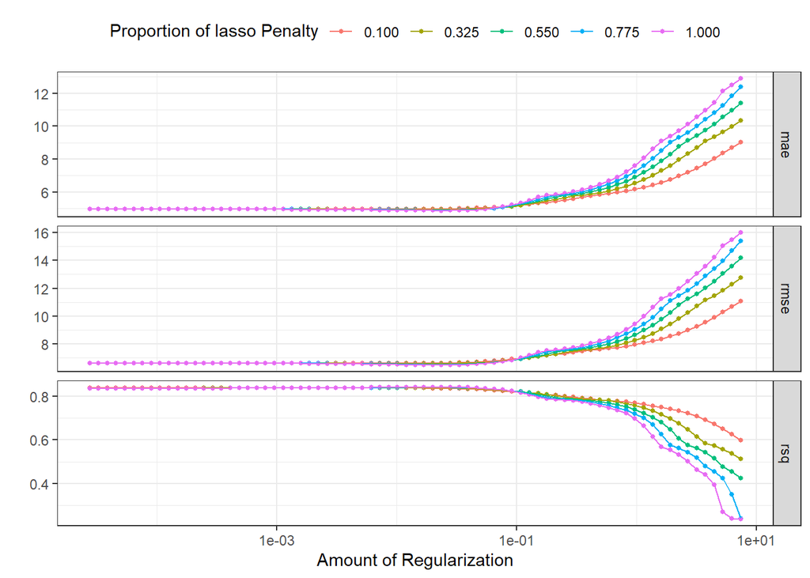

```r
enet_res %>% autoplot() +
  theme_bw() +
  theme(legend.position = "top")
```

Alternatively, we can create our own figure, in order to include the standard errors on the average performance.

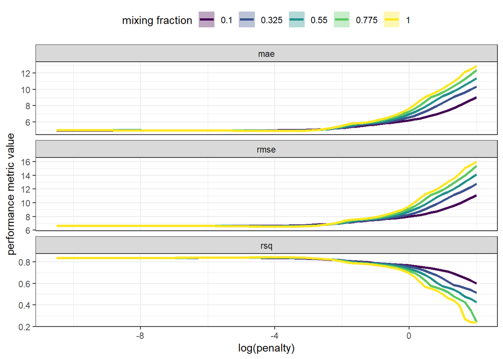

```r
enet_res %>% collect_metrics() %>%
  ggplot(mapping = aes(x = log(penalty))) +
  geom_ribbon(mapping = aes(ymin = mean - std_err,
                            ymax = mean + std_err,
                            group = interaction(mixture, .metric),
                            fill = as.factor(mixture)),
              alpha = 0.35) +
  geom_line(mapping = aes(y = mean,
                          group = interaction(mixture, .metric),
                          color = as.factor(mixture)),
            size = 1.15) +
  facet_wrap(~.metric, scales = "free_y", ncol = 1) +
  scale_fill_viridis_d("mixing fraction") +
  scale_color_viridis_d("mixing fraction") +
  labs(y = "performance metric value") +
  theme_bw() +
  theme(legend.position = "top")
```

Since the above figure is rather busy, let’s instead focus just on the RMSE. As shown below, the RMSE is low regardless of the mixing fraction and roughly constant as long as the `log(penalty)` is less than -4. Larger penalty values, which cause more features to turn-off, result in the performance getting worse, as shown by the increase in the RMSE in the right side of the plot. The mixing fraction starts to become important as more and more features are turned off.

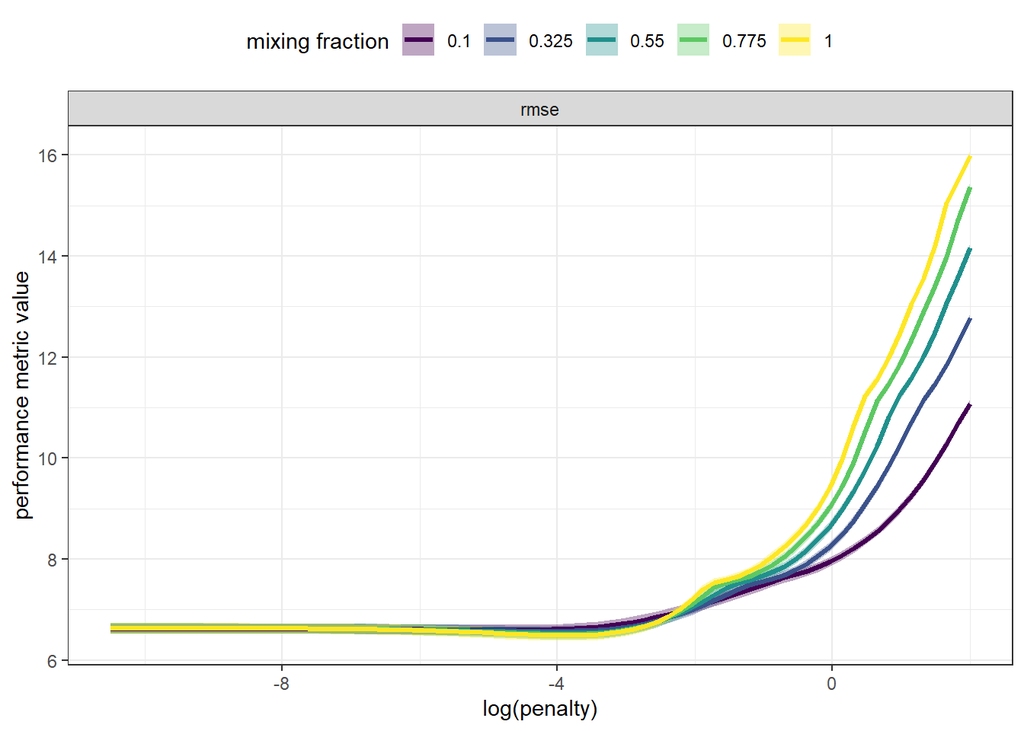

```r
enet_res %>% collect_metrics() %>%
  filter(.metric %in% c("rmse")) %>%
  ggplot(mapping = aes(x = log(penalty))) +
  geom_ribbon(mapping = aes(ymin = mean - std_err,
                            ymax = mean + std_err,
                            group = interaction(mixture, .metric),
                            fill = as.factor(mixture)),
              alpha = 0.35) +
  geom_line(mapping = aes(y = mean,
                          group = interaction(mixture, .metric),
                          color = as.factor(mixture)),
            size = 1.15) +
  facet_wrap(~.metric, scales = "free_y", ncol = 1) +
  scale_fill_viridis_d("mixing fraction") +
  scale_color_viridis_d("mixing fraction") +
  labs(y = 'performance metric value') +
  theme_bw() +
  theme(legend.position = "top")
```

We can identify the best tuning parameter values to use as those which minimize a performance metric. For example, let’s identify the tuning parameters which minimize the RMSE:

```r
enet_res %>% select_best(metric = 'rmse')
```

```
## # A tibble: 1 x 3
##   penalty mixture .config
##     <dbl>   <dbl> <chr>
## 1  0.0237       1 Preprocessor1_Model341
```